# HabitLab analysis

Loading in data:

```r
library(fitdistrplus)
library(ez)
library(lme4)
basepath <- '/Users/msb/Dropbox (Stanford HCI)/projects/habitlab/'
if (!file.exists(basepath)) {
  basepath <- '/home/geza/habitlab_data_analysis/'
}
#basepath <- '/home/geza/habitlab_data_analysis/'
survivaldata_grouped_filename <-paste(basepath, 'oldexp_lifetime_data_april3_4pm.csv', sep='')
survivaldata_filename <-paste(basepath, 'oldexp_lifetime_data_nongrouped_april3_4pm.csv', sep='')
datadays_filename <- paste(basepath, 'data_april3_1am_days.csv', sep='')
#datadays_filename <- paste(basepath, 'data_april16_1am_days.csv', sep='')
data_filename <- paste(basepath, 'data_april3_1am.csv', sep='')
#data_filename <- paste(basepath, 'data_april16_1am.csv', sep='')
dataperuser_filename <- paste(basepath, 'data_april3_1am_peruser.csv', sep='')
choosing_own_intervention_data_filename <- paste(basepath, 'choosing_own_intervention.csv', sep='')
datadays <- read.csv(datadays_filename)
datadays$attritioned_today <- datadays$attritioned_today == 1
datadays$attritioned <- datadays$attritioned == 1
datadays$is_last_day <- datadays$is_last_day == 1
datadays$is_day_with_just_one_sample <- datadays$is_day_with_just_one_sample == 1
datadays$user_saw_both_same_and_random <- datadays$user_saw_both_same_and_random == 1
datadays$condition <- factor(datadays$condition, levels=c("same", "random"))
summary(datadays)
```

```
 attritioned     attritioned_today  condition   conditionduration days_since_install days_until_last_day
 Mode :logical   Mode :logical     same  :383   Min.   :1.000     Min.   : 0.000     Min.   : 0.000
 FALSE:942       FALSE:896         random:700   1st Qu.:3.000     1st Qu.: 0.000     1st Qu.: 0.000
 TRUE :141       TRUE :187                      Median :5.000     Median : 1.000     Median : 3.000
                                                Mean   :4.769     Mean   : 3.297     Mean   : 4.657
                                                3rd Qu.:7.000     3rd Qu.: 5.000     3rd Qu.: 8.000
                                                Max.   :7.000     Max.   :21.000     Max.   :21.000

              domain    first_condition_for_user first_conditionduration_for_user
 www.facebook.com:367   random:577               Min.   :1.00
 www.youtube.com :259   same  :506               1st Qu.:3.00
 www.reddit.com  : 85                            Median :5.00
 twitter.com     : 79                            Mean   :4.08
 vk.com          : 43                            3rd Qu.:5.00
 mail.google.com : 39                            Max.   :7.00
 (Other)         :211
                    install_id                          intervention is_day_with_just_one_sample
 2f896b92139ebf9807f58060: 32   random                        :700   Mode :logical
 f681bdeb2a1effcf9560775f: 21   youtube/remove_comment_section: 42   FALSE:417
 0b94aae6dd4f097e52d373d0: 17   youtube/remove_sidebar_links  : 38   TRUE :666
 589f71f9e47b51205667bea9: 17   youtube/prompt_before_watch   : 37
 7da293a938e52adab6f54ba0: 17   facebook/feed_injection_timer : 26
 3f4c43d216621cd3484c80c3: 16   facebook/show_timer_banner    : 23
 (Other)                 :963   (Other)                       :217
 is_last_day     log_time_spent  num_days_in_same_condition
 Mode :logical   Min.   :0.000   Min.   :0.0000
 FALSE:784       1st Qu.:3.541   1st Qu.:0.0000
 TRUE :299       Median :4.852   Median :0.0000
                 Mean   :4.786   Mean   :0.5005
                 3rd Qu.:6.094   3rd Qu.:1.0000
                 Max.   :9.367   Max.   :7.0000

 num_days_in_same_condition_and_saw_intervention num_days_saw_intervention_for_same_intervention
 Min.   :0.0000                                  Min.   :0.0000
 1st Qu.:0.0000                                  1st Qu.:0.0000
 Median :0.0000                                  Median :0.0000
 Mean   :0.5005                                  Mean   :0.1616
 3rd Qu.:1.0000                                  3rd Qu.:0.0000
 Max.   :7.0000                                  Max.   :9.0000

 num_impressions_on_day num_visits_to_domain_today   time_spent      user_saw_both_same_and_random
 Min.   : 0.000         Min.   : 1.000             Min.   :    1.0   Mode :logical
 1st Qu.: 0.000         1st Qu.: 1.000             1st Qu.:   34.5   FALSE:370
 Median : 0.000         Median : 1.000             Median :  128.0   TRUE :713
 Mean   : 1.245         Mean   : 2.245             Mean   :  435.2
 3rd Qu.: 1.000         3rd Qu.: 2.000             3rd Qu.:  443.0
 Max.   :62.000         Max.   :63.000             Max.   :11693.0

                      userid
 2f896b92139ebf9807f58060: 32
 f681bdeb2a1effcf9560775f: 21
 0b94aae6dd4f097e52d373d0: 17
 589f71f9e47b51205667bea9: 17
 7da293a938e52adab6f54ba0: 17
 3f4c43d216621cd3484c80c3: 16
 (Other)                 :963
```

Reading in the per-session data:

```r
data <- read.csv(data_filename)
data$attritioned <- data$attritioned == 1
data$is_first_visit_of_day <- data$is_first_visit_of_day == 1
data$is_day_with_just_one_sample <- data$is_day_with_just_one_sample == 1
data$condition <- factor(data$condition, levels=c('same', 'random'))
summary(data)
```

```
 attritioned      condition    conditionduration days_since_install days_until_last_day
 Mode :logical   same  :1156   Min.   :1.000     Min.   : 0.000     Min.   : 0.000
 FALSE:2290      random:1275   1st Qu.:3.000     1st Qu.: 0.000     1st Qu.: 1.000
 TRUE :141                     Median :5.000     Median : 2.000     Median : 4.000
                               Mean   :4.849     Mean   : 3.899     Mean   : 4.911
                               3rd Qu.:7.000     3rd Qu.: 7.000     3rd Qu.: 8.000
                               Max.   :7.000     Max.   :21.000     Max.   :21.000

                    domain    first_condition_for_user first_conditionduration_for_user impression_idx
 www.facebook.com      :972   random:1061              Min.   :1.000                    Min.   :  0.00
 www.reddit.com        :422   same  :1370              1st Qu.:1.000                    1st Qu.:  0.00
 www.youtube.com       :405                            Median :3.000                    Median :  0.00
 twitter.com           :108                            Mean   :3.683                    Mean   : 12.87
 vk.com                :102                            3rd Qu.:5.000                    3rd Qu.: 14.00
 houston.craigslist.org: 56                            Max.   :7.000                    Max.   :134.00
 (Other)               :366
 impression_idx_within_day                    install_id                          intervention
 Min.   : 0.000            2f896b92139ebf9807f58060: 203   reddit/toast_notifications   : 231
 1st Qu.: 0.000            bb2fc095e94ef125ea1abe61: 151   facebook/remove_news_feed    : 218
 Median : 0.000            18732c57dfe59d056afbe1cb: 109   facebook/toast_notifications : 205
 Mean   : 3.089            fd727a1f33638fd017e4f889:  95   facebook/feed_injection_timer: 176
 3rd Qu.: 2.000            3f4c43d216621cd3484c80c3:  82   reddit/show_timer_banner     : 161
 Max.   :62.000            dcdd5489380dd97c564ed083:  59   facebook/show_timer_banner   : 159
                           (Other)                 :1732   (Other)                      :1281
 is_day_with_just_one_sample is_first_visit_of_day log_time_spent
 Mode :logical               Mode :logical         Min.   :0.000
 FALSE:1765                  FALSE:813             1st Qu.:2.485
 TRUE :666                   TRUE :1618            Median :3.829
                                                   Mean   :3.792
                                                   3rd Qu.:5.069
                                                   Max.   :9.367

 num_days_intervention_seen_at_least_once   time_spent        timestamp
 Min.   : 0.000                           Min.   :    1.0   Min.   :1.521e+12
 1st Qu.: 0.000                           1st Qu.:   12.0   1st Qu.:1.522e+12
 Median : 0.000                           Median :   46.0   Median :1.522e+12
 Mean   : 1.349                           Mean   :  193.9   Mean   :1.522e+12
 3rd Qu.: 2.000                           3rd Qu.:  159.0   3rd Qu.:1.522e+12
 Max.   :14.000                           Max.   :11693.0   Max.   :1.523e+12

                      userid
 2f896b92139ebf9807f58060: 203
 bb2fc095e94ef125ea1abe61: 151
 18732c57dfe59d056afbe1cb: 109
 fd727a1f33638fd017e4f889:  95
 3f4c43d216621cd3484c80c3:  82
 dcdd5489380dd97c564ed083:  59
 (Other)                 :1732
```

Reading in the per-user data used for survival analysis

```r
data_peruser <- read.csv(dataperuser_filename)
data_peruser$attritioned <- data_peruser$attritioned == 1
data_peruser$attritioned_during_first_condition <- data_peruser$attritioned_during_first_condition == 1
data_peruser$did_not_complete_first_condition <- data_peruser$completed_first_condition == 0
data_peruser$completed_first_condition <- data_peruser$completed_first_condition == 1
summary(data_peruser)
```

```
 attritioned     attritioned_during_first_condition completed_first_condition days_kept_installed
 Mode :logical   Mode :logical                      Mode :logical             Min.   : 0.000
 FALSE:76        FALSE:144                          FALSE:113                 1st Qu.: 0.000
 TRUE :141       TRUE :73                           TRUE :104                 Median : 2.000
                                                                              Mean   : 4.636
                                                                              3rd Qu.: 7.000
                                                                              Max.   :21.000

 first_condition_for_user first_conditionduration_for_user                    install_id
 random:120               Min.   :1.000                    001759e5af383d861c7b02b5:  1
 same  : 97               1st Qu.:3.000                    06d80d6afa3f1fc8ba8eb47f:  1
                          Median :5.000                    07b811c2ce81c4533ea52df4:  1
                          Mean   :4.124                    07c09e33df1c91f7d77ed696:  1
                          3rd Qu.:7.000                    0825c041b139e5c53871a0b9:  1
                          Max.   :7.000                    08c5e36f3aaf25825a206b92:  1
                                                           (Other)                 :211
 did_not_complete_first_condition
 Mode :logical
 FALSE:104
 TRUE :113
```

Reading in the survival data from the old experiment

```r
survivaldata <- read.csv(survivaldata_filename)
summary(survivaldata)
```

```
       condition    attritioned        lifetime
 random     :122   Min.   :0.0000   Min.   : 0.00
 random_half:105   1st Qu.:0.0000   1st Qu.:12.00
 same       :110   Median :0.0000   Median :37.00
                   Mean   :0.4777   Mean   :32.64
                   3rd Qu.:1.0000   3rd Qu.:54.00
                   Max.   :1.0000   Max.   :68.00
```

```r
survivaldata_grouped <- read.csv(survivaldata_grouped_filename)
summary(survivaldata_grouped)
```

```
  condition    attritioned        lifetime
 random:227   Min.   :0.0000   Min.   : 0.00
 same  :110   1st Qu.:0.0000   1st Qu.:12.00
              Median :0.0000   Median :37.00
              Mean   :0.4777   Mean   :32.64
              3rd Qu.:1.0000   3rd Qu.:54.00
              Max.   :1.0000   Max.   :68.00
```

```r
choosing_own_intervention_data <- read.csv(choosing_own_intervention_data_filename)
summary(choosing_own_intervention_data)
```

```
     condition    attritioned        lifetime
 changed  :715   Min.   :0.0000   Min.   : 0.00
 nochanged:338   1st Qu.:0.0000   1st Qu.:12.00
                 Median :0.0000   Median :40.00
                 Mean   :0.4758   Mean   :34.83
                 3rd Qu.:1.0000   3rd Qu.:56.00
                 Max.   :1.0000   Max.   :73.00
```

Filter to Facebook data

```r
datadays_facebook <- subset(datadays, datadays$domain == "www.facebook.com")
datadays_facebook <- subset(datadays_facebook, datadays_facebook$intervention == 'random' | datadays_facebook$intervention == 'facebook/feed_injection_timer' | datadays_facebook$intervention == "facebook/remove_news_feed" | datadays_facebook$intervention == "facebook/remove_comments" | datadays_facebook$intervention == 'facebook/toast_notifications' | datadays_facebook$intervention == 'facebook/show_timer_banner')
data_facebook <- subset(data, domain == "www.facebook.com")
data_facebook <- subset(data_facebook, intervention == 'random' | intervention == 'facebook/feed_injection_timer' | intervention == "facebook/remove_news_feed" | intervention == "facebook/remove_comments" | intervention == 'facebook/toast_notifications' | intervention == 'facebook/show_timer_banner')
```

Exclude first and last days (incomplete observations) when analyzing at the day level

```r
datadays_nofirstlast <- subset(datadays, days_since_install > 0 & days_until_last_day > 0)
datadays_facebook_nofirstlast <- subset(datadays_facebook, days_since_install > 0 & days_until_last_day > 0)
```

Number of users in dataset

```r
length(unique(data$userid))
```

```
[1] 217
```

```r
length(unique(datadays$userid))
```

```
[1] 217
```

```r
length(unique(datadays_nofirstlast$userid))
```

```
[1] 103
```

```r
length(unique(datadays_facebook$userid))
```

```
[1] 137
```

```r
length(unique(datadays_facebook_nofirstlast$userid))
```

```
[1] 75
```

```r
ndata <- subset(datadays_nofirstlast, domain == 'www.facebook.com' | domain == 'www.youtube.com' | domain == 'www.reddit.com' | domain == 'twitter.com' | domain == 'vk.com' | domain == 'www.amazon.com')
summary(ndata)
```

```
 attritioned     attritioned_today  condition   conditionduration days_since_install days_until_last_day
 Mode :logical   Mode :logical     same  :124   Min.   :1.000     Min.   : 1.000     Min.   : 1.000
 FALSE:370       FALSE:370         random:246   1st Qu.:3.000     1st Qu.: 2.000     1st Qu.: 2.000
                                                Median :5.000     Median : 4.000     Median : 5.000
                                                Mean   :4.989     Mean   : 4.957     Mean   : 5.751
                                                3rd Qu.:7.000     3rd Qu.: 7.000     3rd Qu.: 9.000
                                                Max.   :7.000     Max.   :20.000     Max.   :20.000

              domain    first_condition_for_user first_conditionduration_for_user
 www.facebook.com:170   random:191               Min.   :1.000
 www.youtube.com : 82   same  :179               1st Qu.:1.000
 www.reddit.com  : 41                            Median :3.000
 twitter.com     : 38                            Mean   :3.811
 vk.com          : 23                            3rd Qu.:5.000
 www.amazon.com  : 16                            Max.   :7.000
 (Other)         :  0
                    install_id                         intervention is_day_with_just_one_sample
 f681bdeb2a1effcf9560775f: 18   random                       :246   Mode :logical
 3f4c43d216621cd3484c80c3: 14   facebook/remove_news_feed    : 14   FALSE:156
 589f71f9e47b51205667bea9: 14   facebook/toast_notifications : 13   TRUE :214
 bb2fc095e94ef125ea1abe61: 13   facebook/show_timer_banner   : 12
 2f896b92139ebf9807f58060: 11   reddit/toast_notifications   : 11
 fd727a1f33638fd017e4f889: 11   facebook/feed_injection_timer: 10
 (Other)                 :289   (Other)                      : 64
 is_last_day     log_time_spent   num_days_in_same_condition
 Mode :logical   Min.   :0.6931   Min.   :0.0000
 FALSE:368       1st Qu.:3.7612   1st Qu.:0.0000
 TRUE :2         Median :5.1150   Median :0.0000
                 Mean   :5.0151   Mean   :0.9135
                 3rd Qu.:6.3288   3rd Qu.:1.0000
                 Max.   :8.9832   Max.   :6.0000

 num_days_in_same_condition_and_saw_intervention num_days_saw_intervention_for_same_intervention
 Min.   :0.0000                                  Min.   :0.0000
 1st Qu.:0.0000                                  1st Qu.:0.0000
 Median :0.0000                                  Median :0.0000
 Mean   :0.9135                                  Mean   :0.3892
 3rd Qu.:1.0000                                  3rd Qu.:0.0000
 Max.   :6.0000                                  Max.   :8.0000

 num_impressions_on_day num_visits_to_domain_today   time_spent     user_saw_both_same_and_random
 Min.   : 0.000         Min.   : 1.000             Min.   :   2.0   Mode :logical
 1st Qu.: 0.000         1st Qu.: 1.000             1st Qu.:  43.0   FALSE:62
 Median : 0.000         Median : 1.000             Median : 166.5   TRUE :308
 Mean   : 1.824         Mean   : 2.824             Mean   : 510.7
 3rd Qu.: 2.000         3rd Qu.: 3.000             3rd Qu.: 560.5
 Max.   :62.000         Max.   :63.000             Max.   :7968.0

                      userid
 f681bdeb2a1effcf9560775f: 18
 3f4c43d216621cd3484c80c3: 14
 589f71f9e47b51205667bea9: 14
 bb2fc095e94ef125ea1abe61: 13
 2f896b92139ebf9807f58060: 11
 fd727a1f33638fd017e4f889: 11
 (Other)                 :289
```

```r
# GENERATES table 3
ndata <- subset(datadays_nofirstlast, domain == 'www.facebook.com' | domain == 'www.youtube.com' | domain == 'www.reddit.com' | domain == 'twitter.com' | domain == 'vk.com' | domain == 'www.amazon.com')
ndata$condition <- factor(ndata$condition, levels=c('same', 'random'))
mean(ndata$log_time_spent[ndata$condition == "same"])
```

```
[1] 5.388655
```

```r
mean(ndata$log_time_spent[ndata$condition == "random"])
```

```
[1] 4.826813
```

```r
results <- lmer(log_time_spent ~  condition + conditionduration + (1|domain) + (1|install_id), data = ndata)
resultsnull <- lmer(log_time_spent ~ conditionduration + (1|domain) + (1|install_id), data = ndata)
anova(resultsnull, results)
```

```
refitting model(s) with ML (instead of REML)
```

```
Data: ndata
Models:
resultsnull: log_time_spent ~ conditionduration + (1 | domain) + (1 | install_id)
results: log_time_spent ~ condition + conditionduration + (1 | domain) +
results:     (1 | install_id)
            Df    AIC    BIC  logLik deviance  Chisq Chi Df Pr(>Chisq)
resultsnull  5 1433.2 1452.7 -711.58   1423.2
results      6 1430.3 1453.8 -709.14   1418.3 4.8763      1    0.02723 *
---
Signif. codes:  0 '***' 0.001 '**' 0.01 '*' 0.05 '.' 0.1 ' ' 1
```

```r
summary(results)
```

```
Linear mixed model fit by REML ['lmerMod']
Formula: log_time_spent ~ condition + conditionduration + (1 | domain) +      (1 | install_id)
   Data: ndata

REML criterion at convergence: 1425.3

Scaled residuals:
     Min       1Q   Median       3Q      Max
-2.80167 -0.61100  0.07455  0.69047  2.22074

Random effects:
 Groups     Name        Variance Std.Dev.
 install_id (Intercept) 0.7325   0.8559
 domain     (Intercept) 0.1743   0.4174
 Residual               2.2018   1.4838
Number of obs: 370, groups:  install_id, 99; domain, 6

Fixed effects:
                  Estimate Std. Error t value
(Intercept)        4.98079    0.34635  14.381
conditionrandom   -0.41709    0.19026  -2.192
conditionduration  0.01780    0.04772   0.373

Correlation of Fixed Effects:
            (Intr) cndtnr
conditnrndm -0.327
conditndrtn -0.671 -0.057
```

```r
library(stargazer)
stargazer(results,
          covariate.labels = c("Rotation (baseline: static)", "Block length", "(Intercept)"),
          dep.var.labels=c("Log time spent per day", "(Intercept)"),
          no.space=TRUE,
          title="Daily time spent on sites in the static and rotation conditions. Users spend less time per day on sites in the random condition.",
          label="tab:effectiveness_same_vs_random",
          keep.stat="n",
          table.placement = "tb",
          star.cutoffs = c(0.05, 0.01, 0.001)
          )
```

```
% Table created by stargazer v.5.2 by Marek Hlavac, Harvard University. E-mail: hlavac at fas.harvard.edu
% Date and time: Thu, Apr 19, 2018 - 08:47:45
\begin{table}[tb] \centering
  \caption{Daily time spent on sites in the static and rotation conditions. Users spend less time per day on sites in the random condition.}
  \label{tab:effectiveness_same_vs_random}
\begin{tabular}{@{\extracolsep{5pt}}lc}
\\[-1.8ex]\hline
\hline \\[-1.8ex]
 & \multicolumn{1}{c}{\textit{Dependent variable:}} \\
\cline{2-2}
\\[-1.8ex] & Log time spent per day \\
\hline \\[-1.8ex]
 Rotation (baseline: static) & $-$0.417$^{*}$ \\
  & (0.190) \\
  Block length & 0.018 \\
  & (0.048) \\
  (Intercept) & 4.981$^{***}$ \\
  & (0.346) \\
 \hline \\[-1.8ex]
Observations & 370 \\
\hline
\hline \\[-1.8ex]
\textit{Note:}  & \multicolumn{1}{r}{$^{*}$p$<$0.05; $^{**}$p$<$0.01; $^{***}$p$<$0.001} \\
\end{tabular}
\end{table}
```

```r
ndata <- subset(datadays_nofirstlast, domain == 'www.facebook.com' | domain == 'www.youtube.com' | domain == 'www.reddit.com' | domain == 'twitter.com' | domain == 'vk.com')
ndata$condition <- factor(ndata$condition, levels=c('same', 'random'))
mean(ndata$log_time_spent[ndata$condition == "same"])
```

```
[1] 5.484174
```

```r
mean(ndata$log_time_spent[ndata$condition == "random"])
```

```
[1] 4.837031
```

```r
results <- lmer(log_time_spent ~  condition + factor(conditionduration, levels=c('1', '3', '5', '7')) + (1|domain) + (1|install_id), data = ndata)
resultsnull <- lmer(log_time_spent ~ factor(conditionduration, levels=c('1', '3', '5', '7')) + (1|domain) + (1|install_id), data = ndata)
anova(resultsnull, results)
```

```
refitting model(s) with ML (instead of REML)
```

```
Data: ndata
Models:
resultsnull: log_time_spent ~ factor(conditionduration, levels = c("1", "3",
resultsnull:     "5", "7")) + (1 | domain) + (1 | install_id)
results: log_time_spent ~ condition + factor(conditionduration, levels = c("1",
results:     "3", "5", "7")) + (1 | domain) + (1 | install_id)
            Df    AIC    BIC  logLik deviance  Chisq Chi Df Pr(>Chisq)
resultsnull  7 1374.9 1402.0 -680.47   1360.9
results      8 1369.2 1400.2 -676.60   1353.2 7.7339      1   0.005419 **
---
Signif. codes:  0 '***' 0.001 '**' 0.01 '*' 0.05 '.' 0.1 ' ' 1
```

```r
summary(results)
```

```
Linear mixed model fit by REML ['lmerMod']
Formula: log_time_spent ~ condition + factor(conditionduration, levels = c("1",
    "3", "5", "7")) + (1 | domain) + (1 | install_id)
   Data: ndata

REML criterion at convergence: 1358.2

Scaled residuals:
     Min       1Q   Median       3Q      Max
-2.83837 -0.61273  0.08898  0.67922  2.28325

Random effects:
 Groups     Name        Variance Std.Dev.
 install_id (Intercept) 0.8058   0.8977
 domain     (Intercept) 0.1467   0.3830
 Residual               2.1567   1.4686
Number of obs: 354, groups:  install_id, 98; domain, 5

Fixed effects:
                                                           Estimate Std. Error t value
(Intercept)                                                 5.23340    0.39180  13.357
conditionrandom                                            -0.53985    0.19526  -2.765
factor(conditionduration, levels = c("1", "3", "5", "7"))3 -0.11828    0.36807  -0.321
factor(conditionduration, levels = c("1", "3", "5", "7"))5  0.10697    0.36352   0.294
factor(conditionduration, levels = c("1", "3", "5", "7"))7  0.02705    0.34056   0.079

Correlation of Fixed Effects:
                          (Intr) cndtnr f(,l=c("1","3","5","7"))3 f(,l=c("1","3","5","7"))5
conditnrndm               -0.310
f(,l=c("1","3","5","7"))3 -0.670  0.030
f(,l=c("1","3","5","7"))5 -0.660 -0.059  0.665
f(,l=c("1","3","5","7"))7 -0.688 -0.025  0.729                     0.700
```

*SIGNIFICANT* Does condition have an effect on time spent per day?

```r
# GENERATES table 3
ndata <- subset(datadays_nofirstlast, domain == 'www.facebook.com' | domain == 'www.youtube.com' | domain == 'www.reddit.com' | domain == 'twitter.com' | domain == 'vk.com' | domain == 'www.amazon.com')
ndata$condition <- factor(ndata$condition, levels=c('same', 'random'))
mean(ndata$log_time_spent[ndata$condition == "same"])
```

```
[1] 5.388655
```

```r
mean(ndata$log_time_spent[ndata$condition == "random"])
```

```
[1] 4.826813
```

```r
results <- lmer(log_time_spent ~ condition + (1|domain) + (1|install_id), data = ndata)
resultsnull <- lmer(log_time_spent ~ (1|domain) + (1|install_id), data = ndata)
anova(resultsnull, results)
```

```
refitting model(s) with ML (instead of REML)
```

```
Data: ndata
Models:
resultsnull: log_time_spent ~ (1 | domain) + (1 | install_id)
results: log_time_spent ~ condition + (1 | domain) + (1 | install_id)
            Df    AIC    BIC  logLik deviance  Chisq Chi Df Pr(>Chisq)
resultsnull  4 1431.2 1446.9 -711.61   1423.2
results      5 1428.4 1448.0 -709.22   1418.4 4.7886      1    0.02865 *
---
Signif. codes:  0 '***' 0.001 '**' 0.01 '*' 0.05 '.' 0.1 ' ' 1
```

```r
summary(results)
```

```
Linear mixed model fit by REML ['lmerMod']
Formula: log_time_spent ~ condition + (1 | domain) + (1 | install_id)
   Data: ndata

REML criterion at convergence: 1421.2

Scaled residuals:
     Min       1Q   Median       3Q      Max
-2.80195 -0.61398  0.07339  0.69123  2.21670

Random effects:
 Groups     Name        Variance Std.Dev.
 install_id (Intercept) 0.7338   0.8566
 domain     (Intercept) 0.1781   0.4221
 Residual               2.1947   1.4815
Number of obs: 370, groups:  install_id, 99; domain, 6

Fixed effects:
                Estimate Std. Error t value
(Intercept)       5.0668     0.2581  19.633
conditionrandom  -0.4128     0.1897  -2.176

Correlation of Fixed Effects:
            (Intr)
conditnrndm -0.491
```

```r
#install.packages('stargazer')
library(stargazer)
stargazer(results,
          covariate.labels = c("Rotation (baseline: static)", "(Intercept)"),
          dep.var.labels=c("Log time spent per day", "(Intercept)"),
          no.space=TRUE,
          title="Daily time spent on sites in the static and rotation conditions. Users spend less time per day on sites in the random condition.",
          label="tab:effectiveness_same_vs_random",
          keep.stat="n",
          table.placement = "tb"
          )
```

```
% Table created by stargazer v.5.2 by Marek Hlavac, Harvard University. E-mail: hlavac at fas.harvard.edu
% Date and time: Thu, Apr 19, 2018 - 08:47:47
\begin{table}[tb] \centering
  \caption{Daily time spent on sites in the static and rotation conditions. Users spend less time per day on sites in the random condition.}
  \label{tab:effectiveness_same_vs_random}
\begin{tabular}{@{\extracolsep{5pt}}lc}
\\[-1.8ex]\hline
\hline \\[-1.8ex]
 & \multicolumn{1}{c}{\textit{Dependent variable:}} \\
\cline{2-2}
\\[-1.8ex] & Log time spent per day \\
\hline \\[-1.8ex]
 Rotation (baseline: static) & $-$0.413$^{**}$ \\
  & (0.190) \\
  (Intercept) & 5.067$^{***}$ \\
  & (0.258) \\
 \hline \\[-1.8ex]
Observations & 370 \\
\hline
\hline \\[-1.8ex]
\textit{Note:}  & \multicolumn{1}{r}{$^{*}$p$<$0.1; $^{**}$p$<$0.05; $^{***}$p$<$0.01} \\
\end{tabular}
\end{table}
```

*SIGNIFICANT* Does condition have an effect on time spent on Facebook per day?

```r
ndata <- subset(datadays_facebook_nofirstlast, datadays_facebook_nofirstlast$is_day_with_just_one_sample == 0)
#summary(ndata$intervention[ndata$intervention])
#ndata$intervention[ndata$intervention == '']
results <- lmer(log_time_spent ~ condition + (1|install_id), data = ndata)
resultsnull <- lmer(log_time_spent ~ (1|install_id), data = ndata)
anova(resultsnull, results)
```

```
refitting model(s) with ML (instead of REML)
```

```
Data: ndata
Models:
resultsnull: log_time_spent ~ (1 | install_id)
results: log_time_spent ~ condition + (1 | install_id)
            Df    AIC    BIC  logLik deviance  Chisq Chi Df Pr(>Chisq)
resultsnull  3 258.50 265.76 -126.25   252.50
results      4 250.76 260.44 -121.38   242.76 9.7422      1   0.001801 **
---
Signif. codes:  0 '***' 0.001 '**' 0.01 '*' 0.05 '.' 0.1 ' ' 1
```

```r
summary(results)
```

```
Linear mixed model fit by REML ['lmerMod']
Formula: log_time_spent ~ condition + (1 | install_id)
   Data: ndata

REML criterion at convergence: 245.1

Scaled residuals:
     Min       1Q   Median       3Q      Max
-1.99150 -0.51948  0.04512  0.43782  1.84664

Random effects:
 Groups     Name        Variance Std.Dev.
 install_id (Intercept) 1.0026   1.0013
 Residual               0.5923   0.7696
Number of obs: 83, groups:  install_id, 42

Fixed effects:
                Estimate Std. Error t value
(Intercept)       6.1866     0.2921  21.177
conditionrandom  -0.8305     0.2614  -3.177

Correlation of Fixed Effects:
            (Intr)
conditnrndm -0.769
```

```r
library(stargazer)
stargazer(results)
```

```
% Table created by stargazer v.5.2 by Marek Hlavac, Harvard University. E-mail: hlavac at fas.harvard.edu
% Date and time: Thu, Apr 19, 2018 - 08:47:47
\begin{table}[!htbp] \centering
  \caption{}
  \label{}
\begin{tabular}{@{\extracolsep{5pt}}lc}
\\[-1.8ex]\hline
\hline \\[-1.8ex]
 & \multicolumn{1}{c}{\textit{Dependent variable:}} \\
\cline{2-2}
\\[-1.8ex] & log\_time\_spent \\
\hline \\[-1.8ex]
 conditionrandom & $-$0.830$^{***}$ \\
  & (0.261) \\
  & \\
 Constant & 6.187$^{***}$ \\
  & (0.292) \\
  & \\
\hline \\[-1.8ex]
Observations & 83 \\
Log Likelihood & $-$122.575 \\
Akaike Inf. Crit. & 253.149 \\
Bayesian Inf. Crit. & 262.825 \\
\hline
\hline \\[-1.8ex]
\textit{Note:}  & \multicolumn{1}{r}{$^{*}$p$<$0.1; $^{**}$p$<$0.05; $^{***}$p$<$0.01} \\
\end{tabular}
\end{table}
```

Does condition have an effect on time spent on Facebook per day?

```r
results <- lmer(log_time_spent ~ condition + (1|install_id), data = datadays_facebook_nofirstlast)
resultsnull <- lmer(log_time_spent ~ (1|install_id), data = datadays_facebook_nofirstlast)
anova(resultsnull, results)
```

```
refitting model(s) with ML (instead of REML)
```

```
Data: datadays_facebook_nofirstlast
Models:
resultsnull: log_time_spent ~ (1 | install_id)
results: log_time_spent ~ condition + (1 | install_id)
            Df    AIC    BIC  logLik deviance  Chisq Chi Df Pr(>Chisq)
resultsnull  3 581.19 590.44 -287.60   575.19
results      4 581.23 593.55 -286.62   573.23 1.9646      1      0.161
```

```r
summary(results)
```

```
Linear mixed model fit by REML ['lmerMod']
Formula: log_time_spent ~ condition + (1 | install_id)
   Data: datadays_facebook_nofirstlast

REML criterion at convergence: 576

Scaled residuals:
    Min      1Q  Median      3Q     Max
-3.1634 -0.6617  0.1266  0.6527  2.0596

Random effects:
 Groups     Name        Variance Std.Dev.
 install_id (Intercept) 0.9202   0.9593
 Residual               1.4665   1.2110
Number of obs: 161, groups:  install_id, 75

Fixed effects:
                Estimate Std. Error t value
(Intercept)       5.3026     0.2523  21.017
conditionrandom  -0.3610     0.2576  -1.401

Correlation of Fixed Effects:
            (Intr)
conditnrndm -0.785
```

Does condition have an effect on time spent per session on Facebook?

```r
results <- lmer(log_time_spent ~ condition + intervention + (1|install_id), data = data_facebook)
resultsnull <- lmer(log_time_spent ~ intervention + (1|install_id), data = data_facebook)
anova(resultsnull, results)
```

```
refitting model(s) with ML (instead of REML)
```

```
Data: data_facebook
Models:
resultsnull: log_time_spent ~ intervention + (1 | install_id)
results: log_time_spent ~ condition + intervention + (1 | install_id)
            Df    AIC  BIC  logLik deviance  Chisq Chi Df Pr(>Chisq)
resultsnull  7 3198.7 3232 -1592.3   3184.7
results      8 3200.0 3238 -1592.0   3184.0 0.7309      1     0.3926
```

```r
summary(results)
```

```
Linear mixed model fit by REML ['lmerMod']
Formula: log_time_spent ~ condition + intervention + (1 | install_id)
   Data: data_facebook

REML criterion at convergence: 3195.2

Scaled residuals:
    Min      1Q  Median      3Q     Max
-3.3053 -0.6500  0.0317  0.6848  2.6883

Random effects:
 Groups     Name        Variance Std.Dev.
 install_id (Intercept) 0.665    0.8155
 Residual               2.158    1.4691
Number of obs: 854, groups:  install_id, 146

Fixed effects:
                                         Estimate Std. Error t value
(Intercept)                                3.7243     0.1822  20.445
conditionrandom                            0.1201     0.1411   0.851
interventionfacebook/remove_comments       0.2807     0.2229   1.259
interventionfacebook/remove_news_feed     -0.1294     0.2104  -0.615
interventionfacebook/show_timer_banner     0.2839     0.2044   1.389
interventionfacebook/toast_notifications   0.4939     0.2023   2.441

Correlation of Fixed Effects:
                 (Intr) cndtnr intrvntnfcbk/r_ intrvntnfcbk/r__ intrvntnfcbk/s__
conditnrndm      -0.464
intrvntnfcbk/r_  -0.461 -0.131
intrvntnfcbk/r__ -0.546 -0.007  0.464
intrvntnfcbk/s__ -0.553 -0.041  0.483           0.498
intrvntnfcbk/t_  -0.527 -0.110  0.495           0.542            0.528
```

*SIGNIFICANT* Does intervention have an effect on time spent per session on Facebook?

```r
results <- lmer(log_time_spent ~ intervention + (1|install_id), data = data_facebook)
resultsnull <- lmer(log_time_spent ~ (1|install_id), data = data_facebook)
anova(resultsnull, results)
```

```
refitting model(s) with ML (instead of REML)
```

```
Data: data_facebook
Models:
resultsnull: log_time_spent ~ (1 | install_id)
results: log_time_spent ~ intervention + (1 | install_id)
            Df    AIC    BIC  logLik deviance  Chisq Chi Df Pr(>Chisq)
resultsnull  3 3204.0 3218.2 -1599.0   3198.0
results      7 3198.7 3232.0 -1592.3   3184.7 13.262      4    0.01006 *
---
Signif. codes:  0 '***' 0.001 '**' 0.01 '*' 0.05 '.' 0.1 ' ' 1
```

```r
summary(results)
```

```
Linear mixed model fit by REML ['lmerMod']
Formula: log_time_spent ~ intervention + (1 | install_id)
   Data: data_facebook

REML criterion at convergence: 3193.9

Scaled residuals:
    Min      1Q  Median      3Q     Max
-3.3292 -0.6401  0.0301  0.6812  2.6718

Random effects:
 Groups     Name        Variance Std.Dev.
 install_id (Intercept) 0.666    0.8161
 Residual               2.157    1.4687
Number of obs: 854, groups:  install_id, 146

Fixed effects:
                                         Estimate Std. Error t value
(Intercept)                                3.7963     0.1613  23.530
interventionfacebook/remove_comments       0.3057     0.2210   1.383
interventionfacebook/remove_news_feed     -0.1278     0.2104  -0.608
interventionfacebook/show_timer_banner     0.2911     0.2042   1.425
interventionfacebook/toast_notifications   0.5129     0.2011   2.550

Correlation of Fixed Effects:
                 (Intr) intrvntnfcbk/r_ intrvntnfcbk/r__ intrvntnfcbk/s__
intrvntnfcbk/r_  -0.594
intrvntnfcbk/r__ -0.621  0.467
intrvntnfcbk/s__ -0.646  0.482           0.498
intrvntnfcbk/t_  -0.656  0.488           0.544            0.527
```

*SIGNIFICANT* Do interventions decrease in effectiveness over time on Facebook?

```r
#summary(data_facebook$intervention)
library(plyr)
ndata <- data_facebook
ndata$intervention <- revalue(ndata$intervention, c("facebook/feed_injection_timer"="feed_injection_timer"))
ndata$intervention <- revalue(ndata$intervention, c("facebook/remove_news_feed"="remove_news_feed"))
ndata$intervention <- revalue(ndata$intervention, c("facebook/remove_comments"="remove_comments"))
ndata$intervention <- revalue(ndata$intervention, c("facebook/show_timer_banner"="show_timer_banner"))
ndata$intervention <- revalue(ndata$intervention, c("facebook/toast_notifications"="toast_notifications"))
ndata$intervention <- factor(ndata$intervention, levels=c('toast_notifications','remove_news_feed','remove_comments','feed_injection_timer','show_timer_banner'))
#ndata$intervention[ndata$intervention == 'facebook/feed_injection_timer'] <- '0facebook/feed_injection_timer'
#ndata$intervention[ndata$intervention == 'facebook/remove_news_feed'] <- '1facebook/remove_news_feed'
#ndata$intervention[ndata$intervention == 'facebook/remove_comments'] <- '2facebook/remove_comments'
#summary(ndata)
results <- lmer(log_time_spent ~ num_days_intervention_seen_at_least_once + intervention + (1|install_id), data = ndata)
resultsnull <- lmer(log_time_spent ~ intervention + (1|install_id), data = ndata)
anova(resultsnull, results)
```

```
refitting model(s) with ML (instead of REML)
```

```
Data: ndata
Models:
resultsnull: log_time_spent ~ intervention + (1 | install_id)
results: log_time_spent ~ num_days_intervention_seen_at_least_once + intervention +
results:     (1 | install_id)
            Df    AIC    BIC  logLik deviance  Chisq Chi Df Pr(>Chisq)
resultsnull  7 3198.7 3232.0 -1592.3   3184.7
results      8 3194.8 3232.8 -1589.4   3178.8 5.9273      1    0.01491 *
---
Signif. codes:  0 '***' 0.001 '**' 0.01 '*' 0.05 '.' 0.1 ' ' 1
```

```r
summary(results)
```

```
Linear mixed model fit by REML ['lmerMod']
Formula: log_time_spent ~ num_days_intervention_seen_at_least_once + intervention +
    (1 | install_id)
   Data: ndata

REML criterion at convergence: 3193.8

Scaled residuals:
    Min      1Q  Median      3Q     Max
-3.4111 -0.6313  0.0282  0.6687  2.6616

Random effects:
 Groups     Name        Variance Std.Dev.
 install_id (Intercept) 0.6908   0.8311
 Residual               2.1366   1.4617
Number of obs: 854, groups:  install_id, 146

Fixed effects:
                                         Estimate Std. Error t value
(Intercept)                               4.30202    0.15482  27.787
num_days_intervention_seen_at_least_once  0.05242    0.02147   2.441
interventionremove_news_feed             -0.68560    0.19690  -3.482
interventionremove_comments              -0.20168    0.21353  -0.945
interventionfeed_injection_timer         -0.51543    0.20050  -2.571
interventionshow_timer_banner            -0.24078    0.19652  -1.225

Correlation of Fixed Effects:
            (Intr) n_____ intrvntnr__ intrv_ intrvntnf__
nm_dys_____ -0.020
intrvntnr__ -0.559 -0.100
intrvntnrm_ -0.561  0.011  0.412
intrvntnf__ -0.613 -0.003  0.439       0.435
intrvntns__ -0.613 -0.037  0.444       0.446  0.474
```

```r
#install.packages('stargazer')
library(stargazer)
stargazer(results)
```

```
% Table created by stargazer v.5.2 by Marek Hlavac, Harvard University. E-mail: hlavac at fas.harvard.edu
% Date and time: Thu, Apr 19, 2018 - 08:47:50
\begin{table}[!htbp] \centering
  \caption{}
  \label{}
\begin{tabular}{@{\extracolsep{5pt}}lc}
\\[-1.8ex]\hline
\hline \\[-1.8ex]
 & \multicolumn{1}{c}{\textit{Dependent variable:}} \\
\cline{2-2}
\\[-1.8ex] & log\_time\_spent \\
\hline \\[-1.8ex]
 num\_days\_intervention\_seen\_at\_least\_once & 0.052$^{**}$ \\
  & (0.021) \\
  & \\
 interventionremove\_news\_feed & $-$0.686$^{***}$ \\
  & (0.197) \\
  & \\
 interventionremove\_comments & $-$0.202 \\
  & (0.214) \\
  & \\
 interventionfeed\_injection\_timer & $-$0.515$^{**}$ \\
  & (0.200) \\
  & \\
 interventionshow\_timer\_banner & $-$0.241 \\
  & (0.197) \\
  & \\
 Constant & 4.302$^{***}$ \\
  & (0.155) \\
  & \\
\hline \\[-1.8ex]
Observations & 854 \\
Log Likelihood & $-$1,596.913 \\
Akaike Inf. Crit. & 3,209.827 \\
Bayesian Inf. Crit. & 3,247.826 \\
\hline
\hline \\[-1.8ex]
\textit{Note:}  & \multicolumn{1}{r}{$^{*}$p$<$0.1; $^{**}$p$<$0.05; $^{***}$p$<$0.01} \\
\end{tabular}
\end{table}
```

```r
results <- lmer(log_time_spent ~ impression_idx + is_first_visit_of_day + intervention + (1|install_id), data = subset(data_facebook, condition == 'same'))
resultsnull <- lmer(log_time_spent ~ is_first_visit_of_day + intervention + (1|install_id), data = subset(data_facebook, condition == 'same'))
anova(resultsnull, results)
```

```
refitting model(s) with ML (instead of REML)
```

```
Data: subset(data_facebook, condition == "same")
Models:
resultsnull: log_time_spent ~ is_first_visit_of_day + intervention + (1 |
resultsnull:     install_id)
results: log_time_spent ~ impression_idx + is_first_visit_of_day + intervention +
results:     (1 | install_id)
            Df    AIC    BIC  logLik deviance  Chisq Chi Df Pr(>Chisq)
resultsnull  8 1642.4 1674.9 -813.18   1626.4
results      9 1634.9 1671.5 -808.46   1616.9 9.4384      1   0.002125 **
---
Signif. codes:  0 '***' 0.001 '**' 0.01 '*' 0.05 '.' 0.1 ' ' 1
```

```r
summary(results)
```

```
Linear mixed model fit by REML ['lmerMod']
Formula: log_time_spent ~ impression_idx + is_first_visit_of_day + intervention +      (1 | install_id)
   Data: subset(data_facebook, condition == "same")

REML criterion at convergence: 1629.8

Scaled residuals:
    Min      1Q  Median      3Q     Max
-3.2288 -0.6930  0.0232  0.6839  2.7548

Random effects:
 Groups     Name        Variance Std.Dev.
 install_id (Intercept) 0.725    0.8515
 Residual               2.274    1.5079
Number of obs: 432, groups:  install_id, 84

Fixed effects:
                                          Estimate Std. Error t value
(Intercept)                               3.453954   0.330839  10.440
impression_idx                            0.009606   0.003060   3.139
is_first_visit_of_dayTRUE                 0.434904   0.228681   1.902
interventionfacebook/remove_comments      0.689964   0.506642   1.362
interventionfacebook/remove_news_feed    -0.739065   0.427403  -1.729
interventionfacebook/show_timer_banner    0.444248   0.405661   1.095
interventionfacebook/toast_notifications  0.315654   0.409096   0.772

Correlation of Fixed Effects:
                 (Intr) imprs_ i____T intrvntnfcbk/r_ intrvntnfcbk/r__ intrvntnfcbk/s__
impressn_dx      -0.147
is_f___TRUE      -0.550  0.198
intrvntnfcbk/r_  -0.446  0.006  0.043
intrvntnfcbk/r__ -0.454 -0.078 -0.021  0.324
intrvntnfcbk/s__ -0.502 -0.007 -0.061  0.370           0.372
intrvntnfcbk/t_  -0.487 -0.020 -0.070  0.386           0.383            0.425
```

*SIGNIFICANT* Do interventions decrease in effectiveness over time on Facebook?

```r
results <- lmer(log_time_spent ~ impression_idx + is_first_visit_of_day + intervention + (1|install_id), data = data_facebook)
resultsnull <- lmer(log_time_spent ~ is_first_visit_of_day + intervention + (1|install_id), data = data_facebook)
anova(resultsnull, results)
```

```
refitting model(s) with ML (instead of REML)
```

```
Data: data_facebook
Models:
resultsnull: log_time_spent ~ is_first_visit_of_day + intervention + (1 |
resultsnull:     install_id)
results: log_time_spent ~ impression_idx + is_first_visit_of_day + intervention +
results:     (1 | install_id)
            Df    AIC    BIC  logLik deviance  Chisq Chi Df Pr(>Chisq)
resultsnull  8 3193.5 3231.5 -1588.8   3177.5
results      9 3188.7 3231.5 -1585.3   3170.7 6.8087      1   0.009071 **
---
Signif. codes:  0 '***' 0.001 '**' 0.01 '*' 0.05 '.' 0.1 ' ' 1
```

```r
summary(results)
```

```
Linear mixed model fit by REML ['lmerMod']
Formula: log_time_spent ~ impression_idx + is_first_visit_of_day + intervention +      (1 | install_id)
   Data: data_facebook

REML criterion at convergence: 3191.8

Scaled residuals:
    Min      1Q  Median      3Q     Max
-3.2993 -0.6426  0.0147  0.6520  2.7863

Random effects:
 Groups     Name        Variance Std.Dev.
 install_id (Intercept) 0.7048   0.8395
 Residual               2.1135   1.4538
Number of obs: 854, groups:  install_id, 146

Fixed effects:
                                          Estimate Std. Error t value
(Intercept)                               3.302682   0.220462  14.981
impression_idx                            0.006771   0.002593   2.611
is_first_visit_of_dayTRUE                 0.529534   0.165186   3.206
interventionfacebook/remove_comments      0.303343   0.219362   1.383
interventionfacebook/remove_news_feed    -0.178120   0.209816  -0.849
interventionfacebook/show_timer_banner    0.284652   0.202748   1.404
interventionfacebook/toast_notifications  0.524711   0.199828   2.626

Correlation of Fixed Effects:
                 (Intr) imprs_ i____T intrvntnfcbk/r_ intrvntnfcbk/r__ intrvntnfcbk/s__
impressn_dx      -0.172
is_f___TRUE      -0.682  0.217
intrvntnfcbk/r_  -0.419  0.018 -0.019
intrvntnfcbk/r__ -0.429 -0.099 -0.026  0.464
intrvntnfcbk/s__ -0.460  0.004 -0.014  0.482           0.496
intrvntnfcbk/t_  -0.471  0.038 -0.010  0.489           0.538            0.528
```

Do interventions decrease in effectiveness over time on all sites?

```r
results <- lmer(log_time_spent ~ num_days_intervention_seen_at_least_once + intervention + (1|install_id), data = data)
resultsnull <- lmer(log_time_spent ~ intervention + (1|install_id), data = data)
anova(resultsnull, results)
```

```
refitting model(s) with ML (instead of REML)
```

```
Data: data
Models:
resultsnull: log_time_spent ~ intervention + (1 | install_id)
results: log_time_spent ~ num_days_intervention_seen_at_least_once + intervention +
results:     (1 | install_id)
             Df    AIC   BIC  logLik deviance  Chisq Chi Df Pr(>Chisq)
resultsnull 242 9459.9 10863 -4488.0   8975.9
results     243 9460.3 10869 -4487.2   8974.3 1.6125      1     0.2041
```

```r
summary(results)
```

```
Linear mixed model fit by REML ['lmerMod']
Formula: log_time_spent ~ num_days_intervention_seen_at_least_once + intervention +
    (1 | install_id)
   Data: data

REML criterion at convergence: 8484.1

Scaled residuals:
    Min      1Q  Median      3Q     Max
-3.1567 -0.5968  0.0000  0.6190  3.4571

Random effects:
 Groups     Name        Variance Std.Dev.
 install_id (Intercept) 0.5036   0.7097
 Residual               2.4023   1.5499
Number of obs: 2431, groups:  install_id, 217

Fixed effects:
                                                                                    Estimate Std. Error
(Intercept)                                                                          1.17751    1.56609
num_days_intervention_seen_at_least_once                                             0.02097    0.01754
interventionamazon/hide_recommendations                                              2.58520    1.62588
interventionamazon/show_timer_banner                                                 2.01343    1.57524
interventionamazon/show_user_info_interstitial                                       3.15700    2.19193
interventionamazon/toast_notifications                                               2.13163    1.65997
interventionfacebook/block_after_interval_per_visit                                  0.53584    1.60922
interventionfacebook/close_tab_timer                                                 0.90613    1.62290
interventionfacebook/feed_injection_timer                                            2.68752    1.57236
interventionfacebook/make_user_wait                                                  1.17565    1.62318
interventionfacebook/remove_clickbait                                                2.48217    1.59937
interventionfacebook/remove_comments                                                 2.99075    1.57449
interventionfacebook/remove_news_feed                                                2.38993    1.57351
interventionfacebook/rich_notifications                                              2.30805    1.60072
interventionfacebook/scroll_blocker                                                  1.10047    1.64513
interventionfacebook/show_timer_banner                                               2.92862    1.57194
interventionfacebook/show_user_info_interstitial                                     0.75556    1.61944
interventionfacebook/toast_notifications                                             3.09378    1.57187
interventiongenerated_agar.io/close_tab_timer                                       -0.69441    2.22000
interventiongenerated_agar.io/show_timer_banner                                      3.89339    1.67122
interventiongenerated_beta.hulu.com/make_user_wait                                   4.19725    2.23562
```

[output cut: 447 more lines]

```
interventionreddit/toast_notifications                                                1.576
interventiontwitter/block_after_interval_per_visit                                    1.573
interventiontwitter/close_tab_timer                                                   1.114
interventiontwitter/make_user_wait                                                    1.291
interventiontwitter/remove_twitter_feed                                               2.008
interventiontwitter/scroll_blocker                                                    1.606
interventiontwitter/show_timer_banner                                                 1.762
interventiontwitter/show_user_info_interstitial                                       0.836
interventiontwitter/toast_notifications                                               1.926
interventionyoutube/block_after_interval_per_visit                                    1.189
interventionyoutube/prompt_before_watch                                               1.907
interventionyoutube/remove_comment_section                                            2.106
interventionyoutube/remove_sidebar_links                                              2.031
interventionyoutube/show_timer_banner                                                 1.702
interventionyoutube/toast_notifications                                               1.682
```

```
Correlation matrix not shown by default, as p = 241 > 12.
Use print(x, correlation=TRUE)  or
     vcov(x)     if you need it
```

```r
results <- lmer(log_time_spent ~ num_days_intervention_seen_at_least_once + (1|domain) + (1|install_id), data = subset(data, condition == 'random'))
resultsnull <- lmer(log_time_spent ~ (1|domain) + (1|install_id), data = subset(data, condition == 'random'))
anova(resultsnull, results)
```

```
refitting model(s) with ML (instead of REML)
```

```
Data: subset(data, condition == "random")
Models:
resultsnull: log_time_spent ~ (1 | domain) + (1 | install_id)
results: log_time_spent ~ num_days_intervention_seen_at_least_once + (1 |
results:     domain) + (1 | install_id)
            Df    AIC    BIC  logLik deviance  Chisq Chi Df Pr(>Chisq)
resultsnull  4 4910.3 4930.9 -2451.2   4902.3
results      5 4912.1 4937.8 -2451.1   4902.1 0.2147      1     0.6431
```

```r
summary(results)
```

```
Linear mixed model fit by REML ['lmerMod']
Formula: log_time_spent ~ num_days_intervention_seen_at_least_once + (1 |
    domain) + (1 | install_id)
   Data: subset(data, condition == "random")

REML criterion at convergence: 4908.9

Scaled residuals:
     Min       1Q   Median       3Q      Max
-2.79686 -0.65146  0.01542  0.68897  2.56316

Random effects:
 Groups     Name        Variance Std.Dev.
 install_id (Intercept) 0.5889   0.7674
 domain     (Intercept) 0.3598   0.5998
 Residual               2.3547   1.5345
Number of obs: 1275, groups:  install_id, 178; domain, 68

Fixed effects:
                                         Estimate Std. Error t value
(Intercept)                               4.06328    0.14698  27.646
num_days_intervention_seen_at_least_once  0.01687    0.03655   0.462

Correlation of Fixed Effects:
            (Intr)
nm_dys_____ -0.039
```

```r
#stargazer(results)
```

```r
results <- lmer(log_time_spent ~ num_days_intervention_seen_at_least_once + (1|install_id), data = subset(data, condition == 'same' & domain == 'www.facebook.com'))
resultsnull <- lmer(log_time_spent ~ (1|install_id), data = subset(data, condition == 'same' & domain == 'www.facebook.com'))
anova(resultsnull, results)
```

```
refitting model(s) with ML (instead of REML)
```

```
Data: subset(data, condition == "same" & domain == "www.facebook.com")
Models:
resultsnull: log_time_spent ~ (1 | install_id)
results: log_time_spent ~ num_days_intervention_seen_at_least_once + (1 |
results:     install_id)
            Df    AIC    BIC  logLik deviance  Chisq Chi Df Pr(>Chisq)
resultsnull  3 1814.2 1826.7 -904.12   1808.2
results      4 1803.2 1819.8 -897.61   1795.2 13.032      1  0.0003062 ***
---
Signif. codes:  0 '***' 0.001 '**' 0.01 '*' 0.05 '.' 0.1 ' ' 1
```

```r
summary(results)
```

```
Linear mixed model fit by REML ['lmerMod']
Formula: log_time_spent ~ num_days_intervention_seen_at_least_once + (1 |      install_id)
   Data: subset(data, condition == "same" & domain == "www.facebook.com")

REML criterion at convergence: 1802.2

Scaled residuals:
     Min       1Q   Median       3Q      Max
-3.14575 -0.63096  0.03504  0.65490  2.51411

Random effects:
 Groups     Name        Variance Std.Dev.
 install_id (Intercept) 1.022    1.011
 Residual               2.496    1.580
Number of obs: 464, groups:  install_id, 89

Fixed effects:
                                         Estimate Std. Error t value
(Intercept)                               3.69758    0.17229  21.461
num_days_intervention_seen_at_least_once  0.10406    0.02821   3.688

Correlation of Fixed Effects:
            (Intr)
nm_dys_____ -0.107
```

```r
results <- lmer(log_time_spent ~ impression_idx + (1|install_id), data = subset(data, condition == 'same' & domain == 'www.facebook.com'))
resultsnull <- lmer(log_time_spent ~ (1|install_id), data = subset(data, condition == 'same' & domain == 'www.facebook.com'))
anova(resultsnull, results)
```

```
refitting model(s) with ML (instead of REML)
```

```
Data: subset(data, condition == "same" & domain == "www.facebook.com")
Models:
resultsnull: log_time_spent ~ (1 | install_id)
results: log_time_spent ~ impression_idx + (1 | install_id)
            Df    AIC    BIC  logLik deviance  Chisq Chi Df Pr(>Chisq)
resultsnull  3 1814.2 1826.7 -904.12   1808.2
results      4 1807.7 1824.3 -899.85   1799.7 8.5456      1   0.003464 **
---
Signif. codes:  0 '***' 0.001 '**' 0.01 '*' 0.05 '.' 0.1 ' ' 1
```

```r
summary(results)
```

```
Linear mixed model fit by REML ['lmerMod']
Formula: log_time_spent ~ impression_idx + (1 | install_id)
   Data: subset(data, condition == "same" & domain == "www.facebook.com")

REML criterion at convergence: 1811.1

Scaled residuals:
     Min       1Q   Median       3Q      Max
-3.10287 -0.64480  0.04685  0.67177  2.57827

Random effects:
 Groups     Name        Variance Std.Dev.
 install_id (Intercept) 0.996    0.998
 Residual               2.527    1.590
Number of obs: 464, groups:  install_id, 89

Fixed effects:
               Estimate Std. Error t value
(Intercept)    3.716449   0.171514  21.668
impression_idx 0.009447   0.003165   2.985

Correlation of Fixed Effects:
            (Intr)
impressn_dx -0.092
```

```r
results <- lmer(log_time_spent ~ impression_idx + (1|domain) + (1|install_id), data = subset(data, condition == 'same'))
resultsnull <- lmer(log_time_spent ~ (1|domain) + (1|install_id), data = subset(data, condition == 'same'))
anova(resultsnull, results)
```

```
refitting model(s) with ML (instead of REML)
```

```
Data: subset(data, condition == "same")
Models:
resultsnull: log_time_spent ~ (1 | domain) + (1 | install_id)
results: log_time_spent ~ impression_idx + (1 | domain) + (1 | install_id)
            Df    AIC    BIC  logLik deviance  Chisq Chi Df Pr(>Chisq)
resultsnull  4 4490.1 4510.3 -2241.1   4482.1
results      5 4487.8 4513.0 -2238.9   4477.8 4.3402      1    0.03722 *
---
Signif. codes:  0 '***' 0.001 '**' 0.01 '*' 0.05 '.' 0.1 ' ' 1
```

```r
summary(results)
```

```
Linear mixed model fit by REML ['lmerMod']
Formula: log_time_spent ~ impression_idx + (1 | domain) + (1 | install_id)
   Data: subset(data, condition == "same")

REML criterion at convergence: 4490.4

Scaled residuals:
    Min      1Q  Median      3Q     Max
-2.9931 -0.6349  0.0147  0.6928  3.3906

Random effects:
 Groups     Name        Variance Std.Dev.
 install_id (Intercept) 0.60489  0.7777
 domain     (Intercept) 0.05077  0.2253
 Residual               2.59384  1.6105
Number of obs: 1156, groups:  install_id, 133; domain, 50

Fixed effects:
               Estimate Std. Error t value
(Intercept)    3.977946   0.134869  29.495
impression_idx 0.004732   0.002239   2.113

Correlation of Fixed Effects:
            (Intr)
impressn_dx -0.070
```

```r
ndata <- subset(data, domain == 'www.facebook.com' | domain == 'www.youtube.com' | domain == 'www.reddit.com' | domain == 'twitter.com' | domain == 'vk.com')
#summary(ndata)
results <- lmer(log_time_spent ~ num_days_intervention_seen_at_least_once + (1|domain) + (1|install_id), data = subset(ndata, condition == 'random'))
resultsnull <- lmer(log_time_spent ~ (1|domain) + (1|install_id), data = subset(ndata, condition == 'random'))
anova(resultsnull, results)
```

```
refitting model(s) with ML (instead of REML)
```

```
Data: subset(ndata, condition == "random")
Models:
resultsnull: log_time_spent ~ (1 | domain) + (1 | install_id)
results: log_time_spent ~ num_days_intervention_seen_at_least_once + (1 |
results:     domain) + (1 | install_id)
            Df    AIC    BIC  logLik deviance Chisq Chi Df Pr(>Chisq)
resultsnull  4 3980.5 4000.2 -1986.2   3972.5
results      5 3982.4 4007.1 -1986.2   3972.4 0.034      1     0.8537
```

```r
summary(results)
```

```
Linear mixed model fit by REML ['lmerMod']
Formula: log_time_spent ~ num_days_intervention_seen_at_least_once + (1 |
    domain) + (1 | install_id)
   Data: subset(ndata, condition == "random")

REML criterion at convergence: 3978.2

Scaled residuals:
     Min       1Q   Median       3Q      Max
-2.81865 -0.64023  0.02803  0.72825  2.42929

Random effects:
 Groups     Name        Variance Std.Dev.
 install_id (Intercept) 0.6399   0.7999
 domain     (Intercept) 0.2681   0.5178
 Residual               2.3745   1.5409
Number of obs: 1031, groups:  install_id, 171; domain, 5

Fixed effects:
                                         Estimate Std. Error t value
(Intercept)                              3.983565   0.253421  15.719
num_days_intervention_seen_at_least_once 0.007726   0.037746   0.205

Correlation of Fixed Effects:
            (Intr)
nm_dys_____ -0.076
```

```r
#library(stargazer)
#stargazer(results)
```

```r
#ndata <- subset(datadays_nofirstlast, domain == 'www.facebook.com' | domain == 'www.youtube.com' | domain == 'www.reddit.com' | domain == 'twitter.com' | domain == 'vk.com')
ndata <- subset(datadays_nofirstlast, domain == 'www.facebook.com' | domain == 'www.youtube.com' | domain == 'www.reddit.com' | domain == 'twitter.com' | domain == 'vk.com' | domain == 'www.amazon.com')
#ndata <- subset(ndata, is_last_day == FALSE)
#ndata <- subset(datadays_nofirstlast, domain == 'www.facebook.com')
ndata <- subset(ndata, condition == 'same')
#summary(ndata)
#results <- lmer(log_time_spent ~ num_days_in_same_condition + (1|install_id), data = ndata)
#results <- lmer(log_time_spent ~ num_days_saw_intervention_for_same_intervention + (1|domain) + (1|install_id), data = ndata)
#resultsnull <- lmer(log_time_spent ~ (1|domain) + (1|install_id), data = ndata)
results <- lmer(log_time_spent ~ num_days_saw_intervention_for_same_intervention + (1|domain) + (1|install_id), data = ndata)
resultsnull <- lmer(log_time_spent ~ (1|domain) + (1|install_id), data = ndata)
anova(resultsnull, results)
```

```
refitting model(s) with ML (instead of REML)
```

```
Data: ndata
Models:
resultsnull: log_time_spent ~ (1 | domain) + (1 | install_id)
results: log_time_spent ~ num_days_saw_intervention_for_same_intervention +
results:     (1 | domain) + (1 | install_id)
            Df    AIC    BIC  logLik deviance  Chisq Chi Df Pr(>Chisq)
resultsnull  4 493.68 504.96 -242.84   485.68
results      5 490.99 505.09 -240.50   480.99 4.6882      1    0.03037 *
---
Signif. codes:  0 '***' 0.001 '**' 0.01 '*' 0.05 '.' 0.1 ' ' 1
```

```r
summary(results)
```

```
Linear mixed model fit by REML ['lmerMod']
Formula: log_time_spent ~ num_days_saw_intervention_for_same_intervention +
    (1 | domain) + (1 | install_id)
   Data: ndata

REML criterion at convergence: 484

Scaled residuals:
     Min       1Q   Median       3Q      Max
-2.14975 -0.67291  0.05763  0.67022  2.42294

Random effects:
 Groups     Name        Variance Std.Dev.
 install_id (Intercept) 1.1597   1.0769
 domain     (Intercept) 0.5221   0.7226
 Residual               1.9748   1.4053
Number of obs: 124, groups:  install_id, 50; domain, 6

Fixed effects:
                                                Estimate Std. Error t value
(Intercept)                                      4.75856    0.39215  12.134
num_days_saw_intervention_for_same_intervention  0.22534    0.09667   2.331

Correlation of Fixed Effects:
            (Intr)
nm_dys_____ -0.174
```

```r
stargazer(results,
          covariate.labels = c("Number of days the user had seen the static intervention", "(Intercept)"),
          dep.var.labels=c("Log time spent per day"),
          no.space=TRUE,
          title="Within the static condition, interventions decline in effectiveness, with longer visit lengths increasing with the number of days seeing the same static intervention.",
          label="tab:effectiveness_sessions_alldomain_vs_num_days_same",
          keep.stat="n",
          table.placement = "tb",
          star.cutoffs = c(0.05, 0.01, 0.001)
)
```

```
% Table created by stargazer v.5.2 by Marek Hlavac, Harvard University. E-mail: hlavac at fas.harvard.edu
% Date and time: Thu, Apr 19, 2018 - 08:48:03
\begin{table}[tb] \centering
  \caption{Within the static condition, interventions decline in effectiveness, with longer visit lengths increasing with the number of days seeing the same static intervention.}
  \label{tab:effectiveness_sessions_alldomain_vs_num_days_same}
\begin{tabular}{@{\extracolsep{5pt}}lc}
\\[-1.8ex]\hline
\hline \\[-1.8ex]
 & \multicolumn{1}{c}{\textit{Dependent variable:}} \\
\cline{2-2}
\\[-1.8ex] & Log time spent per day \\
\hline \\[-1.8ex]
 Number of days the user had seen the static intervention & 0.225$^{*}$ \\
  & (0.097) \\
  (Intercept) & 4.759$^{***}$ \\
  & (0.392) \\
 \hline \\[-1.8ex]
Observations & 124 \\
\hline
\hline \\[-1.8ex]
\textit{Note:}  & \multicolumn{1}{r}{$^{*}$p$<$0.05; $^{**}$p$<$0.01; $^{***}$p$<$0.001} \\
\end{tabular}
\end{table}
```

```r
#results <- lmer(log_time_spent ~ num_days_intervention_seen_at_least_once + (1|domain) + (1|install_id), data = subset(ndata, condition == 'same'))
#resultsnull <- lmer(log_time_spent ~ (1|domain) + (1|install_id), data = subset(ndata, condition == 'same'))
#anova(resultsnull, results)
#summary(results)
```

```r
# GENERATES table 2
# generates tab:effectiveness_sessions_alldomains_vs_num_days_same
ndata <- subset(data, domain == 'www.facebook.com' | domain == 'www.youtube.com' | domain == 'www.reddit.com' | domain == 'twitter.com' | domain == 'vk.com' | domain == 'www.amazon.com')
results <- lmer(log_time_spent ~ num_days_intervention_seen_at_least_once + (1|domain) + (1|install_id), data = subset(ndata, condition == 'same'))
resultsnull <- lmer(log_time_spent ~ (1|domain) + (1|install_id), data = subset(ndata, condition == 'same'))
anova(resultsnull, results)
```

```
refitting model(s) with ML (instead of REML)
```

```
Data: subset(ndata, condition == "same")
Models:
resultsnull: log_time_spent ~ (1 | domain) + (1 | install_id)
results: log_time_spent ~ num_days_intervention_seen_at_least_once + (1 |
results:     domain) + (1 | install_id)
            Df    AIC    BIC  logLik deviance  Chisq Chi Df Pr(>Chisq)
resultsnull  4 3929.2 3948.8 -1960.6   3921.2
results      5 3924.5 3949.1 -1957.2   3914.5 6.6918      1   0.009686 **
---
Signif. codes:  0 '***' 0.001 '**' 0.01 '*' 0.05 '.' 0.1 ' ' 1
```

```r
summary(results)
```

```
Linear mixed model fit by REML ['lmerMod']
Formula: log_time_spent ~ num_days_intervention_seen_at_least_once + (1 |
    domain) + (1 | install_id)
   Data: subset(ndata, condition == "same")

REML criterion at convergence: 3922.5

Scaled residuals:
    Min      1Q  Median      3Q     Max
-3.0836 -0.6733  0.0353  0.7060  3.3826

Random effects:
 Groups     Name        Variance Std.Dev.
 install_id (Intercept) 0.61667  0.7853
 domain     (Intercept) 0.02973  0.1724
 Residual               2.63255  1.6225
Number of obs: 1007, groups:  install_id, 124; domain, 6

Fixed effects:
                                         Estimate Std. Error t value
(Intercept)                               3.82561    0.14253   26.84
num_days_intervention_seen_at_least_once  0.05633    0.02134    2.64

Correlation of Fixed Effects:
            (Intr)
nm_dys_____ -0.122
```

```r
library(stargazer)
stargazer(results,
          covariate.labels = c("Number of days the intervention has been seen", "(Intercept)"),
          dep.var.labels=c("Log time spent per session"),
          no.space=TRUE,
          title="Within the same condition, interventions decline in effectiveness, with longer visit lengths with increasing larger number of days since it was first observed.",
          label="tab:effectiveness_sessions_alldomain_vs_num_days_same",
          keep.stat="n",
          table.placement = "tb"
)
```

```
% Table created by stargazer v.5.2 by Marek Hlavac, Harvard University. E-mail: hlavac at fas.harvard.edu
% Date and time: Thu, Apr 19, 2018 - 08:48:04
\begin{table}[tb] \centering
  \caption{Within the same condition, interventions decline in effectiveness, with longer visit lengths with increasing larger number of days since it was first observed.}
  \label{tab:effectiveness_sessions_alldomain_vs_num_days_same}
\begin{tabular}{@{\extracolsep{5pt}}lc}
\\[-1.8ex]\hline
\hline \\[-1.8ex]
 & \multicolumn{1}{c}{\textit{Dependent variable:}} \\
\cline{2-2}
\\[-1.8ex] & Log time spent per session \\
\hline \\[-1.8ex]
 Number of days the intervention has been seen & 0.056$^{***}$ \\
  & (0.021) \\
  (Intercept) & 3.826$^{***}$ \\
  & (0.143) \\
 \hline \\[-1.8ex]
Observations & 1,007 \\
\hline
\hline \\[-1.8ex]
\textit{Note:}  & \multicolumn{1}{r}{$^{*}$p$<$0.1; $^{**}$p$<$0.05; $^{***}$p$<$0.01} \\
\end{tabular}
\end{table}
```

Older analyses:

*SIGNIFICANT* Does condition have effect on attrition rates at the day level overall?

```r
results <- glmer(attritioned ~ condition + (1|install_id), family=binomial(link='logit'), data = datadays)
resultsnull <- glmer(attritioned ~ (1|install_id), family=binomial(link='logit'), data = datadays)
anova(resultsnull, results)
```

```
Data: datadays
Models:
resultsnull: attritioned ~ (1 | install_id)
results: attritioned ~ condition + (1 | install_id)
            Df    AIC    BIC  logLik deviance  Chisq Chi Df Pr(>Chisq)
resultsnull  2 838.37 848.35 -417.19   834.37
results      3 834.04 849.01 -414.02   828.04 6.3303      1    0.01187 *
---
Signif. codes:  0 '***' 0.001 '**' 0.01 '*' 0.05 '.' 0.1 ' ' 1
```

```r
summary(results)
```

```
Generalized linear mixed model fit by maximum likelihood (Laplace Approximation) ['glmerMod']
 Family: binomial  ( logit )
Formula: attritioned ~ condition + (1 | install_id)
   Data: datadays

     AIC      BIC   logLik deviance df.resid
     834      849     -414      828     1080

Scaled residuals:
    Min      1Q  Median      3Q     Max
-0.4709 -0.4077 -0.3507 -0.2852  3.5013

Random effects:
 Groups     Name        Variance Std.Dev.
 install_id (Intercept) 0.3125   0.559
Number of obs: 1083, groups:  install_id, 217

Fixed effects:
                Estimate Std. Error z value Pr(>|z|)
(Intercept)      -2.2316     0.1866 -11.957   <2e-16 ***
conditionrandom   0.5265     0.2146   2.453   0.0142 *
---
Signif. codes:  0 '***' 0.001 '**' 0.01 '*' 0.05 '.' 0.1 ' ' 1

Correlation of Fixed Effects:
            (Intr)
conditnrndm -0.833
```

```r
print("Odds ratios")
```

```
[1] "Odds ratios"
```

```r
rtab <- exp(fixef(results))
print(rtab,digits=3)
```

```
    (Intercept) conditionrandom
          0.107           1.693
```

*SIGNIFICANT* Does condition have effect on attrition rates at the day level, on Facebook?

```r
results <- glmer(attritioned ~ condition + (1|install_id), family=binomial(link='logit'), data = datadays_facebook)
resultsnull <- glmer(attritioned ~ (1|install_id), family=binomial(link='logit'), data = datadays_facebook)
```

```
Model failed to converge with max|grad| = 0.0140517 (tol = 0.001, component 1)
```

```r
anova(resultsnull, results)
```

```
Data: datadays_facebook
Models:
resultsnull: attritioned ~ (1 | install_id)
results: attritioned ~ condition + (1 | install_id)
            Df    AIC    BIC  logLik deviance  Chisq Chi Df Pr(>Chisq)
resultsnull  2 289.84 297.36 -142.92   285.84
results      3 284.98 296.26 -139.49   278.98 6.8588      1   0.008821 **
---
Signif. codes:  0 '***' 0.001 '**' 0.01 '*' 0.05 '.' 0.1 ' ' 1
```

```r
summary(results)
```

```
Generalized linear mixed model fit by maximum likelihood (Laplace Approximation) ['glmerMod']
 Family: binomial  ( logit )
Formula: attritioned ~ condition + (1 | install_id)
   Data: datadays_facebook

     AIC      BIC   logLik deviance df.resid
   285.0    296.3   -139.5    279.0      314

Scaled residuals:
    Min      1Q  Median      3Q     Max
-0.4961 -0.4961 -0.4961 -0.2867  3.4881

Random effects:
 Groups     Name        Variance Std.Dev.
 install_id (Intercept) 0        0
Number of obs: 317, groups:  install_id, 137

Fixed effects:
                Estimate Std. Error z value Pr(>|z|)
(Intercept)      -2.4987     0.4247  -5.884 4.02e-09 ***
conditionrandom   1.0966     0.4548   2.411   0.0159 *
---
Signif. codes:  0 '***' 0.001 '**' 0.01 '*' 0.05 '.' 0.1 ' ' 1

Correlation of Fixed Effects:
            (Intr)
conditnrndm -0.934
```

```r
print("Odds ratios")
```

```
[1] "Odds ratios"
```

```r
rtab <- exp(fixef(results))
print(rtab,digits=3)
```

```
    (Intercept) conditionrandom
         0.0822          2.9939
```

*SIGNIFICANT* Does condition have an effect on attrition rates at the session level?

```r
results <- glmer(attritioned ~ condition + (1|install_id), family=binomial(link='logit'), data = data)
resultsnull <- glmer(attritioned ~ (1|install_id), family=binomial(link='logit'), data = data)
anova(resultsnull, results)
```

```
Data: data
Models:
resultsnull: attritioned ~ (1 | install_id)
results: attritioned ~ condition + (1 | install_id)
            Df    AIC    BIC  logLik deviance  Chisq Chi Df Pr(>Chisq)
resultsnull  2 1024.6 1036.2 -510.29   1020.6
results      3 1018.7 1036.1 -506.37   1012.7 7.8313      1   0.005135 **
---
Signif. codes:  0 '***' 0.001 '**' 0.01 '*' 0.05 '.' 0.1 ' ' 1
```

```r
summary(results)
```

```
Generalized linear mixed model fit by maximum likelihood (Laplace Approximation) ['glmerMod']
 Family: binomial  ( logit )
Formula: attritioned ~ condition + (1 | install_id)
   Data: data

     AIC      BIC   logLik deviance df.resid
  1018.7   1036.1   -506.4   1012.7     2428

Scaled residuals:
    Min      1Q  Median      3Q     Max
-0.4246 -0.2726 -0.1899 -0.1152  5.6644

Random effects:
 Groups     Name        Variance Std.Dev.
 install_id (Intercept) 0.9252   0.9619
Number of obs: 2431, groups:  install_id, 217

Fixed effects:
                Estimate Std. Error z value Pr(>|z|)
(Intercept)      -2.9915     0.2062 -14.510  < 2e-16 ***
conditionrandom   0.6357     0.2310   2.752  0.00593 **
---
Signif. codes:  0 '***' 0.001 '**' 0.01 '*' 0.05 '.' 0.1 ' ' 1

Correlation of Fixed Effects:
            (Intr)
conditnrndm -0.816
```

```r
print("Odds ratios")
```

```
[1] "Odds ratios"
```

```r
rtab <- exp(fixef(results))
print(rtab,digits=3)
```

```
    (Intercept) conditionrandom
         0.0502          1.8884
```

*SIGNIFICANT* Does condition have an effect on attrition rates at the session level, on Facebook?

```r
results <- glmer(attritioned ~ condition + intervention + (1|install_id), family=binomial(link='logit'), data = data_facebook)
resultsnull <- glmer(attritioned ~ intervention + (1|install_id), family=binomial(link='logit'), data = data_facebook)
anova(resultsnull, results)
```

```
Data: data_facebook
Models:
resultsnull: attritioned ~ intervention + (1 | install_id)
results: attritioned ~ condition + intervention + (1 | install_id)
            Df    AIC    BIC  logLik deviance  Chisq Chi Df Pr(>Chisq)
resultsnull  6 353.15 381.65 -170.57   341.15
results      7 337.74 370.99 -161.87   323.74 17.406      1  3.018e-05 ***
---
Signif. codes:  0 '***' 0.001 '**' 0.01 '*' 0.05 '.' 0.1 ' ' 1
```

```r
summary(results)
```

```
Generalized linear mixed model fit by maximum likelihood (Laplace Approximation) ['glmerMod']
 Family: binomial  ( logit )
Formula: attritioned ~ condition + intervention + (1 | install_id)
   Data: data_facebook

     AIC      BIC   logLik deviance df.resid
   337.7    371.0   -161.9    323.7      847

Scaled residuals:
    Min      1Q  Median      3Q     Max
-0.5429 -0.2430 -0.1414 -0.0818  8.0831

Random effects:
 Groups     Name        Variance Std.Dev.
 install_id (Intercept) 0.9228   0.9606
Number of obs: 854, groups:  install_id, 146

Fixed effects:
                                         Estimate Std. Error z value Pr(>|z|)
(Intercept)                              -3.79109    0.52585  -7.209 5.62e-13 ***
conditionrandom                           1.90019    0.50472   3.765 0.000167 ***
interventionfacebook/remove_comments     -0.61540    0.53013  -1.161 0.245709
interventionfacebook/remove_news_feed     0.09921    0.46599   0.213 0.831405
interventionfacebook/show_timer_banner   -1.05423    0.54929  -1.919 0.054953 .
interventionfacebook/toast_notifications -0.70742    0.49904  -1.418 0.156319
---
Signif. codes:  0 '***' 0.001 '**' 0.01 '*' 0.05 '.' 0.1 ' ' 1

Correlation of Fixed Effects:
                 (Intr) cndtnr intrvntnfcbk/r_ intrvntnfcbk/r__ intrvntnfcbk/s__
conditnrndm      -0.738
intrvntnfcbk/r_  -0.286 -0.101
intrvntnfcbk/r__ -0.381 -0.091  0.431
intrvntnfcbk/s__ -0.293 -0.095  0.370           0.420
intrvntnfcbk/t_  -0.320 -0.124  0.406           0.473            0.397
```

```r
print("Odds ratios")
```

```
[1] "Odds ratios"
```

```r
rtab <- exp(fixef(results))
print(rtab,digits=3)
```

```
                             (Intercept)                          conditionrandom
                                  0.0226                                   6.6872
    interventionfacebook/remove_comments    interventionfacebook/remove_news_feed
                                  0.5404                                   1.1043
  interventionfacebook/show_timer_banner interventionfacebook/toast_notifications
                                  0.3485                                   0.4929
```

Does condition duration have an effect on attrition rates at the day level?

```r
results <- glmer(attritioned ~ as.factor(conditionduration) + condition + (1|install_id), family=binomial(link='logit'), data = datadays)
resultsnull <- glmer(attritioned ~ condition + (1|install_id), family=binomial(link='logit'), data = datadays)
anova(resultsnull, results)
```

```
Data: datadays
Models:
resultsnull: attritioned ~ condition + (1 | install_id)
results: attritioned ~ as.factor(conditionduration) + condition + (1 |
results:     install_id)
            Df    AIC    BIC  logLik deviance  Chisq Chi Df Pr(>Chisq)
resultsnull  3 834.04 849.01 -414.02   828.04
results      6 839.01 868.94 -413.51   827.01 1.0295      3     0.7941
```

```r
summary(results)
```

```
Generalized linear mixed model fit by maximum likelihood (Laplace Approximation) ['glmerMod']
 Family: binomial  ( logit )
Formula: attritioned ~ as.factor(conditionduration) + condition + (1 |      install_id)
   Data: datadays

     AIC      BIC   logLik deviance df.resid
   839.0    868.9   -413.5    827.0     1077

Scaled residuals:
    Min      1Q  Median      3Q     Max
-0.5183 -0.3981 -0.3534 -0.2893  3.4571

Random effects:
 Groups     Name        Variance Std.Dev.
 install_id (Intercept) 0.2939   0.5421
Number of obs: 1083, groups:  install_id, 217

Fixed effects:
                              Estimate Std. Error z value Pr(>|z|)
(Intercept)                    -2.0266     0.2917  -6.948 3.69e-12 ***
as.factor(conditionduration)3  -0.3164     0.3284  -0.964   0.3353
as.factor(conditionduration)5  -0.2601     0.3164  -0.822   0.4110
as.factor(conditionduration)7  -0.1824     0.3033  -0.601   0.5475
conditionrandom                 0.5287     0.2144   2.466   0.0137 *
---
Signif. codes:  0 '***' 0.001 '**' 0.01 '*' 0.05 '.' 0.1 ' ' 1

Correlation of Fixed Effects:
            (Intr) as.()3 as.()5 as.()7
as.fctr(c)3 -0.642
as.fctr(c)5 -0.666  0.592
as.fctr(c)7 -0.692  0.619  0.669
conditnrndm -0.503 -0.010 -0.039 -0.045
```

Does condition duration have an effect on attrition rates at the day level on Facebook?

```r
results <- glmer(attritioned ~ as.factor(conditionduration) + condition + (1|install_id), family=binomial(link='logit'), data = datadays_facebook)
resultsnull <- glmer(attritioned ~ condition + (1|install_id), family=binomial(link='logit'), data = datadays_facebook)
anova(resultsnull, results)
```

```
Data: datadays_facebook
Models:
resultsnull: attritioned ~ condition + (1 | install_id)
results: attritioned ~ as.factor(conditionduration) + condition + (1 |
results:     install_id)
            Df    AIC    BIC  logLik deviance  Chisq Chi Df Pr(>Chisq)
resultsnull  3 284.98 296.26 -139.49   278.98
results      6 289.49 312.04 -138.75   277.49 1.4922      3     0.6841
```

```r
summary(results)
```

```
Generalized linear mixed model fit by maximum likelihood (Laplace Approximation) ['glmerMod']
 Family: binomial  ( logit )
Formula: attritioned ~ as.factor(conditionduration) + condition + (1 |      install_id)
   Data: datadays_facebook

     AIC      BIC   logLik deviance df.resid
   289.5    312.0   -138.7    277.5      311

Scaled residuals:
    Min      1Q  Median      3Q     Max
-0.5595 -0.5141 -0.4548 -0.2669  3.7472

Random effects:
 Groups     Name        Variance Std.Dev.
 install_id (Intercept) 0        0
Number of obs: 317, groups:  install_id, 137

Fixed effects:
                              Estimate Std. Error z value Pr(>|z|)
(Intercept)                   -2.70041    0.61670  -4.379 1.19e-05 ***
as.factor(conditionduration)3  0.30373    0.57428   0.529   0.5969
as.factor(conditionduration)5  0.47280    0.55881   0.846   0.3975
as.factor(conditionduration)7  0.05839    0.54880   0.106   0.9153
conditionrandom                1.06620    0.45754   2.330   0.0198 *
---
Signif. codes:  0 '***' 0.001 '**' 0.01 '*' 0.05 '.' 0.1 ' ' 1

Correlation of Fixed Effects:
            (Intr) as.()3 as.()5 as.()7
as.fctr(c)3 -0.663
as.fctr(c)5 -0.641  0.732
as.fctr(c)7 -0.674  0.745  0.768
conditnrndm -0.619  0.001 -0.065 -0.033
```

Does condition duration have an effect on attrition rates at the session level?

```r
results <- glmer(attritioned ~ as.factor(conditionduration) + condition + (1|install_id), family=binomial(link='logit'), data = data)
resultsnull <- glmer(attritioned ~ condition + (1|install_id), family=binomial(link='logit'), data = data)
anova(resultsnull, results)
```

```
Data: data
Models:
resultsnull: attritioned ~ condition + (1 | install_id)
results: attritioned ~ as.factor(conditionduration) + condition + (1 |
results:     install_id)
            Df    AIC    BIC  logLik deviance  Chisq Chi Df Pr(>Chisq)
resultsnull  3 1018.7 1036.1 -506.37   1012.7
results      6 1024.2 1058.9 -506.07   1012.1 0.5977      3      0.897
```

```r
summary(results)
```

```
Generalized linear mixed model fit by maximum likelihood (Laplace Approximation) ['glmerMod']
 Family: binomial  ( logit )
Formula: attritioned ~ as.factor(conditionduration) + condition + (1 |      install_id)
   Data: data

     AIC      BIC   logLik deviance df.resid
  1024.1   1058.9   -506.1   1012.1     2425

Scaled residuals:
    Min      1Q  Median      3Q     Max
-0.4427 -0.2691 -0.1869 -0.1175  5.5569

Random effects:
 Groups     Name        Variance Std.Dev.
 install_id (Intercept) 0.9484   0.9738
Number of obs: 2431, groups:  install_id, 217

Fixed effects:
                              Estimate Std. Error z value Pr(>|z|)
(Intercept)                   -2.97508    0.32076  -9.275  < 2e-16 ***
as.factor(conditionduration)3 -0.15166    0.35679  -0.425  0.67078
as.factor(conditionduration)5 -0.02304    0.34463  -0.067  0.94670
as.factor(conditionduration)7  0.07861    0.32707   0.240  0.81006
conditionrandom                0.62903    0.23216   2.709  0.00674 **
---
Signif. codes:  0 '***' 0.001 '**' 0.01 '*' 0.05 '.' 0.1 ' ' 1

Correlation of Fixed Effects:
            (Intr) as.()3 as.()5 as.()7
as.fctr(c)3 -0.634
as.fctr(c)5 -0.653  0.581
as.fctr(c)7 -0.685  0.613  0.645
conditnrndm -0.511  0.011 -0.029 -0.026
```

Does condition duration have an effect on attrition rates at the session level on Facebook?

```r
results <- glmer(attritioned ~ as.factor(conditionduration) + condition + intervention + (1|install_id), family=binomial(link='logit'), data = data_facebook)
```

```
Model failed to converge with max|grad| = 0.415171 (tol = 0.001, component 1)
```

```r
resultsnull <- glmer(attritioned ~ condition + intervention + (1|install_id), family=binomial(link='logit'), data = data_facebook)
anova(resultsnull, results)
```

```
Data: data_facebook
Models:
resultsnull: attritioned ~ condition + intervention + (1 | install_id)
results: attritioned ~ as.factor(conditionduration) + condition + intervention +
results:     (1 | install_id)
            Df    AIC    BIC  logLik deviance  Chisq Chi Df Pr(>Chisq)
resultsnull  7 337.74 370.99 -161.87   323.74
results     10 342.14 389.63 -161.07   322.14 1.6088      3     0.6574
```

```r
summary(results)
```

```
Generalized linear mixed model fit by maximum likelihood (Laplace Approximation) ['glmerMod']
 Family: binomial  ( logit )
Formula: attritioned ~ as.factor(conditionduration) + condition + intervention +      (1 | install_id)
   Data: data_facebook

     AIC      BIC   logLik deviance df.resid
   342.1    389.6   -161.1    322.1      844

Scaled residuals:
    Min      1Q  Median      3Q     Max
-0.5744 -0.2512 -0.1465 -0.0818  8.8780

Random effects:
 Groups     Name        Variance Std.Dev.
 install_id (Intercept) 0.6853   0.8279
Number of obs: 854, groups:  install_id, 146

Fixed effects:
                                         Estimate Std. Error z value Pr(>|z|)
(Intercept)                              -4.17234    0.74841  -5.575 2.48e-08 ***
as.factor(conditionduration)3             0.64246    0.64881   0.990 0.322072
as.factor(conditionduration)5             0.54923    0.63730   0.862 0.388793
as.factor(conditionduration)7             0.26311    0.62934   0.418 0.675888
conditionrandom                           1.95214    0.50291   3.882 0.000104 ***
interventionfacebook/remove_comments     -0.67211    0.52778  -1.273 0.202847
interventionfacebook/remove_news_feed     0.06576    0.46136   0.143 0.886659
interventionfacebook/show_timer_banner   -1.10930    0.54885  -2.021 0.043265 *
interventionfacebook/toast_notifications -0.80156    0.49597  -1.616 0.106061
---
Signif. codes:  0 '***' 0.001 '**' 0.01 '*' 0.05 '.' 0.1 ' ' 1

Correlation of Fixed Effects:
                 (Intr) as.()3 as.()5 as.()7 cndtnr intrvntnfcbk/r_ intrvntnfcbk/r__ intrvntnfcbk/s__
as.fctr(c)3      -0.658
as.fctr(c)5      -0.673  0.730
as.fctr(c)7      -0.667  0.756  0.750
conditnrndm      -0.523  0.032  0.019 -0.003
intrvntnfcbk/r_  -0.189  0.005 -0.022  0.003 -0.092
intrvntnfcbk/r__ -0.301  0.027  0.097  0.048 -0.095  0.410
intrvntnfcbk/s__ -0.167 -0.043  0.005 -0.060 -0.099  0.353           0.411
intrvntnfcbk/t_  -0.216 -0.024  0.027  0.016 -0.134  0.388           0.469            0.386
convergence code: 0
Model failed to converge with max|grad| = 0.415171 (tol = 0.001, component 1)
```

```r
ndata <- subset(datadays_nofirstlast, domain == 'www.facebook.com')
ndata <- subset(ndata, is_day_with_just_one_sample == 0)
results <- lmer(log_time_spent ~ condition + (1|install_id), data = ndata)
resultsnull <- lmer(log_time_spent ~ (1|install_id), data = ndata)
anova(resultsnull, results)
```

```
refitting model(s) with ML (instead of REML)
```

```
Data: ndata
Models:
resultsnull: log_time_spent ~ (1 | install_id)
results: log_time_spent ~ condition + (1 | install_id)
            Df    AIC    BIC  logLik deviance  Chisq Chi Df Pr(>Chisq)
resultsnull  3 262.85 270.18 -128.43   256.85
results      4 254.75 264.52 -123.37   246.75 10.105      1   0.001479 **
---
Signif. codes:  0 '***' 0.001 '**' 0.01 '*' 0.05 '.' 0.1 ' ' 1
```

```r
summary(results)
```

```
Linear mixed model fit by REML ['lmerMod']
Formula: log_time_spent ~ condition + (1 | install_id)
   Data: ndata

REML criterion at convergence: 249.2

Scaled residuals:
     Min       1Q   Median       3Q      Max
-2.01844 -0.52137  0.03928  0.42140  1.87912

Random effects:
 Groups     Name        Variance Std.Dev.
 install_id (Intercept) 0.9937   0.9969
 Residual               0.5744   0.7579
Number of obs: 85, groups:  install_id, 43

Fixed effects:
                Estimate Std. Error t value
(Intercept)       6.1737     0.2809  21.981
conditionrandom  -0.8213     0.2536  -3.238

Correlation of Fixed Effects:
            (Intr)
conditnrndm -0.758
```

```r
results <- lmer(log_time_spent ~ num_days_intervention_seen_at_least_once + condition + (1|domain) + (1|install_id), data = data)
resultsnull <- lmer(log_time_spent ~ condition + (1|domain) + (1|install_id), data = data)
anova(resultsnull, results)
```

```
refitting model(s) with ML (instead of REML)
```

```
Data: data
Models:
resultsnull: log_time_spent ~ condition + (1 | domain) + (1 | install_id)
results: log_time_spent ~ num_days_intervention_seen_at_least_once + condition +
results:     (1 | domain) + (1 | install_id)
            Df    AIC    BIC  logLik deviance  Chisq Chi Df Pr(>Chisq)
resultsnull  5 9397.9 9426.9 -4694.0   9387.9
results      6 9394.3 9429.0 -4691.1   9382.3 5.6772      1    0.01719 *
---
Signif. codes:  0 '***' 0.001 '**' 0.01 '*' 0.05 '.' 0.1 ' ' 1
```

```r
summary(results)
```

```
Linear mixed model fit by REML ['lmerMod']
Formula: log_time_spent ~ num_days_intervention_seen_at_least_once + condition +
    (1 | domain) + (1 | install_id)
   Data: data

REML criterion at convergence: 9394

Scaled residuals:
    Min      1Q  Median      3Q     Max
-3.0328 -0.6454  0.0206  0.7018  3.5034

Random effects:
 Groups     Name        Variance Std.Dev.
 install_id (Intercept) 0.5540   0.7443
 domain     (Intercept) 0.1895   0.4353
 Residual               2.5244   1.5888
Number of obs: 2431, groups:  install_id, 217; domain, 87

Fixed effects:
                                         Estimate Std. Error t value
(Intercept)                               3.87264    0.13085  29.597
num_days_intervention_seen_at_least_once  0.04238    0.01779   2.382
conditionrandom                           0.15765    0.08897   1.772

Correlation of Fixed Effects:
            (Intr) n_____
nm_dys_____ -0.092
conditnrndm -0.440  0.158
```

```r
#stargazer(results)
#t.test(data$num_days_intervention_seen_at_least_once ~ data$condition)
#cor(data$condition, data$num_days_intervention_seen_at_least_once)
```

```r
results <- lmer(log_time_spent ~ num_days_intervention_seen_at_least_once + (1|domain) + (1|install_id), data = data)
resultsnull <- lmer(log_time_spent ~ (1|domain) + (1|install_id), data = data)
anova(resultsnull, results)
```

```
refitting model(s) with ML (instead of REML)
```

```
Data: data
Models:
resultsnull: log_time_spent ~ (1 | domain) + (1 | install_id)
results: log_time_spent ~ num_days_intervention_seen_at_least_once + (1 |
results:     domain) + (1 | install_id)
            Df    AIC    BIC  logLik deviance Chisq Chi Df Pr(>Chisq)
resultsnull  4 9397.9 9421.1 -4695.0   9389.9
results      5 9395.4 9424.4 -4692.7   9385.4 4.536      1    0.03319 *
---
Signif. codes:  0 '***' 0.001 '**' 0.01 '*' 0.05 '.' 0.1 ' ' 1
```

```r
summary(results)
```

```
Linear mixed model fit by REML ['lmerMod']
Formula: log_time_spent ~ num_days_intervention_seen_at_least_once + (1 |
    domain) + (1 | install_id)
   Data: data

REML criterion at convergence: 9394.1

Scaled residuals:
    Min      1Q  Median      3Q     Max
-3.0623 -0.6487  0.0191  0.6974  3.4856

Random effects:
 Groups     Name        Variance Std.Dev.
 install_id (Intercept) 0.5641   0.7511
 domain     (Intercept) 0.1906   0.4366
 Residual               2.5243   1.5888
Number of obs: 2431, groups:  install_id, 217; domain, 87

Fixed effects:
                                         Estimate Std. Error t value
(Intercept)                               3.97497    0.11785   33.73
num_days_intervention_seen_at_least_once  0.03744    0.01758    2.13

Correlation of Fixed Effects:
            (Intr)
nm_dys_____ -0.025
```

*SIGNIFICANT* Do interventions decrease in effectiveness over time on all sites?

```r
results <- lmer(log_time_spent ~ impression_idx + is_first_visit_of_day + intervention + (1|install_id), data = data)
resultsnull <- lmer(log_time_spent ~ is_first_visit_of_day + intervention + (1|install_id), data = data)
anova(resultsnull, results)
```

```
refitting model(s) with ML (instead of REML)
```

```
Data: data
Models:
resultsnull: log_time_spent ~ is_first_visit_of_day + intervention + (1 |
resultsnull:     install_id)
results: log_time_spent ~ impression_idx + is_first_visit_of_day + intervention +
results:     (1 | install_id)
             Df    AIC   BIC  logLik deviance  Chisq Chi Df Pr(>Chisq)
resultsnull 243 9433.5 10842 -4473.8   8947.5
results     244 9431.1 10845 -4471.5   8943.1 4.4712      1    0.03447 *
---
Signif. codes:  0 '***' 0.001 '**' 0.01 '*' 0.05 '.' 0.1 ' ' 1
```

```r
summary(results)
```

```
Linear mixed model fit by REML ['lmerMod']
Formula: log_time_spent ~ impression_idx + is_first_visit_of_day + intervention +      (1 | install_id)
   Data: data

REML criterion at convergence: 8463

Scaled residuals:
    Min      1Q  Median      3Q     Max
-3.1955 -0.5911  0.0000  0.6070  3.5653

Random effects:
 Groups     Name        Variance Std.Dev.
 install_id (Intercept) 0.5105   0.7145
 Residual               2.3696   1.5393
Number of obs: 2431, groups:  install_id, 217

Fixed effects:
                                                                                     Estimate Std. Error
(Intercept)                                                                          0.440681   1.562173
impression_idx                                                                       0.004028   0.002015
is_first_visit_of_dayTRUE                                                            0.584966   0.108442
interventionamazon/hide_recommendations                                              2.742619   1.615537
interventionamazon/show_timer_banner                                                 2.389103   1.565425
interventionamazon/show_user_info_interstitial                                       3.157000   2.176950
interventionamazon/toast_notifications                                               2.251769   1.649228
interventionfacebook/block_after_interval_per_visit                                  0.687803   1.599075
interventionfacebook/close_tab_timer                                                 1.008831   1.612352
interventionfacebook/feed_injection_timer                                            2.920338   1.562958
interventionfacebook/make_user_wait                                                  1.314847   1.612792
interventionfacebook/remove_clickbait                                                2.594296   1.589046
interventionfacebook/remove_comments                                                 3.193162   1.564793
interventionfacebook/remove_news_feed                                                2.592291   1.564216
interventionfacebook/rich_notifications                                              2.469222   1.590610
interventionfacebook/scroll_blocker                                                  1.230778   1.634640
interventionfacebook/show_timer_banner                                               3.148490   1.562272
interventionfacebook/show_user_info_interstitial                                     0.850542   1.609016
interventionfacebook/toast_notifications                                             3.322940   1.562224
interventiongenerated_agar.io/close_tab_timer                                       -0.751356   2.205094
interventiongenerated_agar.io/show_timer_banner                                      4.170939   1.661222
interventiongenerated_beta.hulu.com/make_user_wait                                   4.378415   2.221271
```

[output cut: 448 more lines]

```
interventionreddit/toast_notifications                                                1.842
interventiontwitter/block_after_interval_per_visit                                    1.669
interventiontwitter/close_tab_timer                                                   1.193
interventiontwitter/make_user_wait                                                    1.388
interventiontwitter/remove_twitter_feed                                               2.113
interventiontwitter/scroll_blocker                                                    1.692
interventiontwitter/show_timer_banner                                                 1.879
interventiontwitter/show_user_info_interstitial                                       0.930
interventiontwitter/toast_notifications                                               2.057
interventionyoutube/block_after_interval_per_visit                                    1.293
interventionyoutube/prompt_before_watch                                               2.011
interventionyoutube/remove_comment_section                                            2.254
interventionyoutube/remove_sidebar_links                                              2.166
interventionyoutube/show_timer_banner                                                 1.788
interventionyoutube/toast_notifications                                               1.777
```

```
Correlation matrix not shown by default, as p = 242 > 12.
Use print(x, correlation=TRUE)  or
     vcov(x)     if you need it
```

Does condition duration within the same condition have effect on time spent per session on Facebook?

```r
curdata <- subset(data_facebook, condition == 'same')
results <- lmer(log_time_spent ~ as.factor(conditionduration) + (1|install_id), data = curdata)
resultsnull <- lmer(log_time_spent ~ (1|install_id), data = curdata)
anova(resultsnull, results)
```

```
refitting model(s) with ML (instead of REML)
```

```
Data: curdata
Models:
resultsnull: log_time_spent ~ (1 | install_id)
results: log_time_spent ~ as.factor(conditionduration) + (1 | install_id)
            Df    AIC    BIC  logLik deviance  Chisq Chi Df Pr(>Chisq)
resultsnull  3 1642.7 1654.9 -818.35   1636.7
results      6 1641.7 1666.1 -814.83   1629.7 7.0512      3    0.07028 .
---
Signif. codes:  0 '***' 0.001 '**' 0.01 '*' 0.05 '.' 0.1 ' ' 1
```

```r
summary(results)
```

```
Linear mixed model fit by REML ['lmerMod']
Formula: log_time_spent ~ as.factor(conditionduration) + (1 | install_id)
   Data: curdata

REML criterion at convergence: 1632.8

Scaled residuals:
    Min      1Q  Median      3Q     Max
-3.2363 -0.6866  0.0109  0.7022  2.9296

Random effects:
 Groups     Name        Variance Std.Dev.
 install_id (Intercept) 0.8188   0.9049
 Residual               2.3089   1.5195
Number of obs: 432, groups:  install_id, 84

Fixed effects:
                              Estimate Std. Error t value
(Intercept)                    3.82336    0.37438  10.213
as.factor(conditionduration)3  0.04814    0.42649   0.113
as.factor(conditionduration)5 -0.03214    0.50329  -0.064
as.factor(conditionduration)7  0.55422    0.42122   1.316

Correlation of Fixed Effects:
            (Intr) as.()3 as.()5
as.fctr(c)3 -0.832
as.fctr(c)5 -0.744  0.619
as.fctr(c)7 -0.831  0.881  0.618
```

Does condition duration within the random condition have effect on time spent per session on Facebook?

```r
curdata <- subset(data_facebook, condition == 'random')
results <- lmer(log_time_spent ~ as.factor(conditionduration) + (1|install_id), data = curdata)
resultsnull <- lmer(log_time_spent ~ (1|install_id), data = curdata)
anova(resultsnull, results)
```

```
refitting model(s) with ML (instead of REML)
```

```
Data: curdata
Models:
resultsnull: log_time_spent ~ (1 | install_id)
results: log_time_spent ~ as.factor(conditionduration) + (1 | install_id)
            Df    AIC    BIC  logLik deviance Chisq Chi Df Pr(>Chisq)
resultsnull  3 1569.8 1581.9 -781.88   1563.8
results      6 1575.8 1600.0 -781.88   1563.8 0.008      3     0.9998
```

```r
summary(results)
```

```
Linear mixed model fit by REML ['lmerMod']
Formula: log_time_spent ~ as.factor(conditionduration) + (1 | install_id)
   Data: curdata

REML criterion at convergence: 1569.4

Scaled residuals:
     Min       1Q   Median       3Q      Max
-3.09822 -0.59566  0.01663  0.65996  2.47469

Random effects:
 Groups     Name        Variance Std.Dev.
 install_id (Intercept) 0.7074   0.8411
 Residual               1.9553   1.3983
Number of obs: 422, groups:  install_id, 112

Fixed effects:
                               Estimate Std. Error t value
(Intercept)                    4.015630   0.246526  16.289
as.factor(conditionduration)3  0.007852   0.298850   0.026
as.factor(conditionduration)5  0.002989   0.299643   0.010
as.factor(conditionduration)7 -0.012123   0.274603  -0.044

Correlation of Fixed Effects:
            (Intr) as.()3 as.()5
as.fctr(c)3 -0.743
as.fctr(c)5 -0.774  0.597
as.fctr(c)7 -0.800  0.655  0.630
```

Does condition duration within the same condition have effect on time spent per day on Facebook?

```r
curdata <- subset(datadays_facebook_nofirstlast, condition == 'same')
results <- lmer(log_time_spent ~ as.factor(conditionduration) + (1|install_id), data = curdata)
resultsnull <- lmer(log_time_spent ~ (1|install_id), data = curdata)
anova(resultsnull, results)
```

```
refitting model(s) with ML (instead of REML)
```

```
Data: curdata
Models:
resultsnull: log_time_spent ~ (1 | install_id)
results: log_time_spent ~ as.factor(conditionduration) + (1 | install_id)
            Df    AIC    BIC  logLik deviance  Chisq Chi Df Pr(>Chisq)
resultsnull  3 172.43 178.04 -83.215   166.43
results      6 175.32 186.55 -81.661   163.32 3.1097      3      0.375
```

```r
summary(results)
```

```
Linear mixed model fit by REML ['lmerMod']
Formula: log_time_spent ~ as.factor(conditionduration) + (1 | install_id)
   Data: curdata

REML criterion at convergence: 159.8

Scaled residuals:
     Min       1Q   Median       3Q      Max
-1.57145 -0.48822  0.07688  0.44135  1.95141

Random effects:
 Groups     Name        Variance Std.Dev.
 install_id (Intercept) 2.9912   1.730
 Residual               0.7311   0.855
Number of obs: 48, groups:  install_id, 24

Fixed effects:
                              Estimate Std. Error t value
(Intercept)                     3.8811     0.8628   4.498
as.factor(conditionduration)3   1.6081     1.0129   1.588
as.factor(conditionduration)5   1.6787     1.2793   1.312
as.factor(conditionduration)7   1.6406     1.0126   1.620

Correlation of Fixed Effects:
            (Intr) as.()3 as.()5
as.fctr(c)3 -0.852
as.fctr(c)5 -0.674  0.575
as.fctr(c)7 -0.852  0.913  0.575
```

Does condition duration within the same condition have effect on time spent per day on Facebook?

```r
curdata <- subset(datadays_facebook_nofirstlast, condition == 'same')
results <- lmer(log_time_spent ~ intervention + conditionduration + (1|install_id), data = curdata)
resultsnull <- lmer(log_time_spent ~ intervention + (1|install_id), data = curdata)
anova(resultsnull, results)
```

```
refitting model(s) with ML (instead of REML)
```

```
Data: curdata
Models:
resultsnull: log_time_spent ~ intervention + (1 | install_id)
results: log_time_spent ~ intervention + conditionduration + (1 | install_id)
            Df    AIC    BIC  logLik deviance  Chisq Chi Df Pr(>Chisq)
resultsnull  7 174.43 187.53 -80.214   160.43
results      8 175.86 190.83 -79.928   159.86 0.5727      1     0.4492
```

```r
summary(results)
```

```
Linear mixed model fit by REML ['lmerMod']
Formula: log_time_spent ~ intervention + conditionduration + (1 | install_id)
   Data: curdata

REML criterion at convergence: 154.9

Scaled residuals:
     Min       1Q   Median       3Q      Max
-1.60388 -0.44463  0.07279  0.38943  2.12472

Random effects:
 Groups     Name        Variance Std.Dev.
 install_id (Intercept) 2.8505   1.6883
 Residual               0.7301   0.8545
Number of obs: 48, groups:  install_id, 24

Fixed effects:
                                         Estimate Std. Error t value
(Intercept)                               4.42448    0.81343   5.439
interventionfacebook/remove_comments      2.06972    2.04619   1.012
interventionfacebook/remove_news_feed    -0.25008    1.12047  -0.223
interventionfacebook/show_timer_banner    1.84040    1.07908   1.706
interventionfacebook/toast_notifications  0.12223    1.10286   0.111
conditionduration                         0.05873    0.09963   0.589

Correlation of Fixed Effects:
                 (Intr) intrvntnfcbk/r_ intrvntnfcbk/r__ intrvntnfcbk/s__ intrvntnfcbk/t_
intrvntnfcbk/r_  -0.306
intrvntnfcbk/r__ -0.615  0.251
intrvntnfcbk/s__ -0.601  0.270           0.474
intrvntnfcbk/t_  -0.543  0.275           0.467            0.509
conditndrtn      -0.374 -0.095          -0.026           -0.126           -0.242
```

```r
curdata <- subset(datadays_nofirstlast, condition == 'same')
results <- lmer(log_time_spent ~ as.factor(conditionduration) + intervention + (1|install_id), data = curdata)
resultsnull <- lmer(log_time_spent ~ intervention + (1|install_id), data = curdata)
anova(resultsnull, results)
```

```
refitting model(s) with ML (instead of REML)
```

```
Data: curdata
Models:
resultsnull: log_time_spent ~ intervention + (1 | install_id)
results: log_time_spent ~ as.factor(conditionduration) + intervention +
results:     (1 | install_id)
            Df    AIC    BIC  logLik deviance  Chisq Chi Df Pr(>Chisq)
resultsnull 37 640.27 752.64 -283.14   566.27
results     40 634.93 756.41 -277.47   554.93 11.338      3    0.01003 *
---
Signif. codes:  0 '***' 0.001 '**' 0.01 '*' 0.05 '.' 0.1 ' ' 1
```

```r
summary(results)
```

```
Linear mixed model fit by REML ['lmerMod']
Formula: log_time_spent ~ as.factor(conditionduration) + intervention +      (1 | install_id)
   Data: curdata

REML criterion at convergence: 488.5

Scaled residuals:
     Min       1Q   Median       3Q      Max
-2.60432 -0.44006  0.04665  0.43055  2.64187

Random effects:
 Groups     Name        Variance Std.Dev.
 install_id (Intercept) 1.396    1.181
 Residual               2.112    1.453
Number of obs: 154, groups:  install_id, 59

Fixed effects:
                                                                        Estimate Std. Error t value
(Intercept)                                                            -0.008294   2.044839  -0.004
as.factor(conditionduration)3                                           1.200076   0.732166   1.639
as.factor(conditionduration)5                                           2.087735   0.820484   2.545
as.factor(conditionduration)7                                           1.393146   0.733829   1.898
interventionamazon/show_timer_banner                                    3.063952   2.313608   1.324
interventionfacebook/feed_injection_timer                               3.716900   2.019410   1.841
interventionfacebook/remove_clickbait                                   3.796931   2.702728   1.405
interventionfacebook/remove_comments                                    4.708403   2.648839   1.778
interventionfacebook/remove_news_feed                                   3.625964   2.084776   1.739
interventionfacebook/show_timer_banner                                  5.037181   2.045462   2.463
interventionfacebook/toast_notifications                                3.779082   2.056139   1.838
interventiongenerated_agar.io/show_timer_banner                         6.025984   2.423567   2.486
interventiongenerated_discordapp.com/toast_notifications                4.315544   2.575519   1.676
interventiongenerated_en.wikipedia.org/toast_notifications              3.240120   2.702728   1.199
interventiongenerated_ifttt.com/block_after_interval_per_visit          1.329243   2.330662   0.570
interventiongenerated_imgur.com/show_timer_banner                       4.947948   2.371915   2.086
interventiongenerated_vk.com/show_timer_banner                          5.985272   2.329266   2.570
interventiongenerated_www.boden.co.uk/show_timer_banner                 0.833470   1.678287   0.497
interventiongenerated_www.empornium.me/show_user_info_interstitial      3.149157   2.209625   1.425
interventiongenerated_www.fanfiction.net/show_timer_banner             -0.691706   2.702728  -0.256
interventiongenerated_www.fresharts.org/block_after_interval_per_visit  1.378420   2.441333   0.565
interventiongenerated_www.pornhub.com/toast_notifications               3.975791   2.293962   1.733
interventiongenerated_www.theatlantic.com/scroll_blocker                1.071711   2.345034   0.457
interventiongenerated_www.twitch.tv/toast_notifications                 5.645447   2.648839   2.131
interventiongenerated_www.xvideos.com/show_timer_banner                 3.689108   2.450460   1.505
interventiongmail/show_timer_banner                                     7.992075   2.773002   2.882
interventiongmail/toast_notifications                                   3.824090   2.322104   1.647
interventionnetflix/show_timer_banner                                   4.044493   2.702728   1.496
interventionnetflix/toast_notifications                                 2.324550   2.198831   1.057
interventionreddit/show_timer_banner                                    3.967897   2.104726   1.885
interventionreddit/toast_notifications                                  3.808350   2.033176   1.873
interventiontwitter/remove_twitter_feed                                 2.067205   2.056677   1.005
interventiontwitter/show_timer_banner                                   1.165077   2.025889   0.575
interventiontwitter/toast_notifications                                 3.913304   2.161159   1.811
interventionyoutube/prompt_before_watch                                 3.239358   2.130404   1.521
interventionyoutube/remove_comment_section                              4.495765   2.029657   2.215
interventionyoutube/remove_sidebar_links                                4.095897   2.250125   1.820
interventionyoutube/show_timer_banner                                   4.705371   2.708990   1.737
```

```
Correlation matrix not shown by default, as p = 38 > 12.
Use print(x, correlation=TRUE)  or
     vcov(x)     if you need it
```

*SIGNIFICANT* Does condition duration within the same condition have effect on time spent per day on all sites?

```r
curdata <- subset(datadays_nofirstlast, condition == 'same')
results <- lmer(log_time_spent ~ conditionduration + intervention + (1|install_id), data = curdata)
resultsnull <- lmer(log_time_spent ~ intervention + (1|install_id), data = curdata)
anova(resultsnull, results)
```

```
refitting model(s) with ML (instead of REML)
```

```
Data: curdata
Models:
resultsnull: log_time_spent ~ intervention + (1 | install_id)
results: log_time_spent ~ conditionduration + intervention + (1 | install_id)
            Df    AIC    BIC  logLik deviance Chisq Chi Df Pr(>Chisq)
resultsnull 37 640.27 752.64 -283.14   566.27
results     38 637.35 752.75 -280.67   561.35 4.926      1    0.02646 *
---
Signif. codes:  0 '***' 0.001 '**' 0.01 '*' 0.05 '.' 0.1 ' ' 1
```

```r
summary(results)
```

```
Linear mixed model fit by REML ['lmerMod']
Formula: log_time_spent ~ conditionduration + intervention + (1 | install_id)
   Data: curdata

REML criterion at convergence: 498

Scaled residuals:
     Min       1Q   Median       3Q      Max
-2.57141 -0.42527  0.00359  0.45572  3.05100

Random effects:
 Groups     Name        Variance Std.Dev.
 install_id (Intercept) 1.335    1.155
 Residual               2.191    1.480
Number of obs: 154, groups:  install_id, 59

Fixed effects:
                                                                       Estimate Std. Error t value
(Intercept)                                                             1.44874    1.93413   0.749
conditionduration                                                       0.12614    0.09278   1.360
interventionamazon/show_timer_banner                                    2.38762    2.27833   1.048
interventionfacebook/feed_injection_timer                               3.15046    2.00307   1.573
interventionfacebook/remove_clickbait                                   2.85006    2.66190   1.071
interventionfacebook/remove_comments                                    4.70840    2.65542   1.773
interventionfacebook/remove_news_feed                                   2.77681    2.02551   1.371
interventionfacebook/show_timer_banner                                  4.20658    2.00303   2.100
interventionfacebook/toast_notifications                                2.85720    2.00094   1.428
interventiongenerated_agar.io/show_timer_banner                         5.29125    2.37549   2.227
interventiongenerated_discordapp.com/toast_notifications                2.73237    2.46850   1.107
interventiongenerated_en.wikipedia.org/toast_notifications              2.29325    2.66190   0.862
interventiongenerated_ifttt.com/block_after_interval_per_visit          1.32924    2.32551   0.572
interventiongenerated_imgur.com/show_timer_banner                       3.83867    2.31645   1.657
interventiongenerated_vk.com/show_timer_banner                          5.15521    2.26633   2.275
interventiongenerated_www.boden.co.uk/show_timer_banner                 0.83347    1.70920   0.488
interventiongenerated_www.empornium.me/show_user_info_interstitial      2.35724    2.18710   1.078
interventiongenerated_www.fanfiction.net/show_timer_banner             -1.63857    2.66190  -0.616
interventiongenerated_www.fresharts.org/block_after_interval_per_visit  1.37842    2.44044   0.565
interventiongenerated_www.pornhub.com/toast_notifications               3.97579    2.29966   1.729
interventiongenerated_www.theatlantic.com/scroll_blocker                0.89243    2.35065   0.380
interventiongenerated_www.twitch.tv/toast_notifications                 5.64545    2.65542   2.126
interventiongenerated_www.xvideos.com/show_timer_banner                 3.03395    2.39532   1.267
interventiongmail/show_timer_banner                                     6.40890    2.68123   2.390
interventiongmail/toast_notifications                                   3.20094    2.28156   1.403
interventionnetflix/show_timer_banner                                   3.09763    2.66190   1.164
interventionnetflix/toast_notifications                                 1.86899    2.18799   0.854
interventionreddit/show_timer_banner                                    3.42002    2.08213   1.643
interventionreddit/toast_notifications                                  3.26739    2.00578   1.629
interventiontwitter/remove_twitter_feed                                 1.67982    2.05302   0.818
interventiontwitter/show_timer_banner                                   0.75086    2.01220   0.373
interventiontwitter/toast_notifications                                 2.71845    2.09217   1.299
interventionyoutube/prompt_before_watch                                 2.26304    2.07851   1.089
interventionyoutube/remove_comment_section                              3.79595    1.99239   1.905
interventionyoutube/remove_sidebar_links                                3.71820    2.23075   1.667
interventionyoutube/show_timer_banner                                   4.06999    2.66190   1.529
```

```
Correlation matrix not shown by default, as p = 36 > 12.
Use print(x, correlation=TRUE)  or
     vcov(x)     if you need it
```

Does condition duration within the random condition have effect on time spent per day on Facebook?

```r
curdata <- subset(datadays_facebook, condition == 'random')
results <- lmer(log_time_spent ~ as.factor(conditionduration) + (1|install_id), data = curdata)
resultsnull <- lmer(log_time_spent ~ (1|install_id), data = curdata)
anova(resultsnull, results)
```

```
refitting model(s) with ML (instead of REML)
```

```
Data: curdata
Models:
resultsnull: log_time_spent ~ (1 | install_id)
results: log_time_spent ~ as.factor(conditionduration) + (1 | install_id)
            Df    AIC    BIC  logLik deviance  Chisq Chi Df Pr(>Chisq)
resultsnull  3 907.47 917.89 -450.74   901.47
results      6 912.72 933.55 -450.36   900.72 0.7536      3     0.8605
```

```r
summary(results)
```

```
Linear mixed model fit by REML ['lmerMod']
Formula: log_time_spent ~ as.factor(conditionduration) + (1 | install_id)
   Data: curdata

REML criterion at convergence: 905

Scaled residuals:
    Min      1Q  Median      3Q     Max
-2.5617 -0.5923  0.1605  0.6164  1.9124

Random effects:
 Groups     Name        Variance Std.Dev.
 install_id (Intercept) 0.6289   0.793
 Residual               2.0922   1.446
Number of obs: 238, groups:  install_id, 121

Fixed effects:
                              Estimate Std. Error t value
(Intercept)                    4.70563    0.31629  14.878
as.factor(conditionduration)3  0.11039    0.38893   0.284
as.factor(conditionduration)5 -0.13292    0.37200  -0.357
as.factor(conditionduration)7  0.07932    0.35897   0.221

Correlation of Fixed Effects:
            (Intr) as.()3 as.()5
as.fctr(c)3 -0.790
as.fctr(c)5 -0.815  0.659
as.fctr(c)7 -0.846  0.692  0.697
```

```r
curdata <- subset(datadays_nofirstlast, conditionduration == 1)
results <- lmer(log_time_spent ~ as.factor(condition) + (1|install_id), data = curdata)
resultsnull <- lmer(log_time_spent ~ (1|install_id), data = curdata)
anova(resultsnull, results)
```

```
refitting model(s) with ML (instead of REML)
```

```
Data: curdata
Models:
resultsnull: log_time_spent ~ (1 | install_id)
results: log_time_spent ~ as.factor(condition) + (1 | install_id)
            Df    AIC    BIC  logLik deviance  Chisq Chi Df Pr(>Chisq)
resultsnull  3 157.37 162.12 -75.686   151.37
results      4 158.49 164.83 -75.246   150.49 0.8798      1     0.3483
```

```r
summary(results)
```

```
Linear mixed model fit by REML ['lmerMod']
Formula: log_time_spent ~ as.factor(condition) + (1 | install_id)
   Data: curdata

REML criterion at convergence: 149.8

Scaled residuals:
    Min      1Q  Median      3Q     Max
-2.1570 -0.7722  0.2957  0.6464  1.7824

Random effects:
 Groups     Name        Variance  Std.Dev.
 install_id (Intercept) 4.220e-14 2.054e-07
 Residual               4.054e+00 2.013e+00
Number of obs: 36, groups:  install_id, 24

Fixed effects:
                           Estimate Std. Error t value
(Intercept)                  4.3951     0.5584   7.871
as.factor(condition)random   0.6407     0.6986   0.917

Correlation of Fixed Effects:
            (Intr)
as.fctr(cn) -0.799
```

```r
curdata <- subset(datadays_nofirstlast, conditionduration == 3)
results <- lmer(log_time_spent ~ as.factor(condition) + (1|install_id), data = curdata)
resultsnull <- lmer(log_time_spent ~ (1|install_id), data = curdata)
anova(resultsnull, results)
```

```
refitting model(s) with ML (instead of REML)
```

```
Data: curdata
Models:
resultsnull: log_time_spent ~ (1 | install_id)
results: log_time_spent ~ as.factor(condition) + (1 | install_id)
            Df    AIC    BIC  logLik deviance Chisq Chi Df Pr(>Chisq)
resultsnull  3 401.42 409.27 -197.71   395.42
results      4 401.63 412.09 -196.81   393.63 1.791      1     0.1808
```

```r
summary(results)
```

```
Linear mixed model fit by REML ['lmerMod']
Formula: log_time_spent ~ as.factor(condition) + (1 | install_id)
   Data: curdata

REML criterion at convergence: 395.5

Scaled residuals:
    Min      1Q  Median      3Q     Max
-2.5912 -0.6716  0.1119  0.7190  1.9420

Random effects:
 Groups     Name        Variance Std.Dev.
 install_id (Intercept) 0.1278   0.3575
 Residual               2.8222   1.6799
Number of obs: 101, groups:  install_id, 36

Fixed effects:
                           Estimate Std. Error t value
(Intercept)                  5.1787     0.2725  19.005
as.factor(condition)random  -0.4675     0.3504  -1.334

Correlation of Fixed Effects:
            (Intr)
as.fctr(cn) -0.752
```

```r
curdata <- subset(datadays_nofirstlast, conditionduration == 5)
results <- lmer(log_time_spent ~ as.factor(condition) + (1|install_id), data = curdata)
resultsnull <- lmer(log_time_spent ~ (1|install_id), data = curdata)
anova(resultsnull, results)
```

```
refitting model(s) with ML (instead of REML)
```

```
Data: curdata
Models:
resultsnull: log_time_spent ~ (1 | install_id)
results: log_time_spent ~ as.factor(condition) + (1 | install_id)
            Df    AIC    BIC  logLik deviance Chisq Chi Df Pr(>Chisq)
resultsnull  3 605.92 615.03 -299.96   599.92
results      4 607.78 619.92 -299.89   599.78 0.142      1     0.7063
```

```r
summary(results)
```

```
Linear mixed model fit by REML ['lmerMod']
Formula: log_time_spent ~ as.factor(condition) + (1 | install_id)
   Data: curdata

REML criterion at convergence: 601.6

Scaled residuals:
     Min       1Q   Median       3Q      Max
-2.72184 -0.65633  0.01809  0.64843  2.72436

Random effects:
 Groups     Name        Variance Std.Dev.
 install_id (Intercept) 0.7982   0.8934
 Residual               2.4288   1.5585
Number of obs: 154, groups:  install_id, 34

Fixed effects:
                           Estimate Std. Error t value
(Intercept)                  5.0188     0.3154  15.912
as.factor(condition)random  -0.1178     0.3147  -0.374

Correlation of Fixed Effects:
            (Intr)
as.fctr(cn) -0.746
```

```r
curdata <- subset(datadays_nofirstlast, conditionduration == 7)
results <- lmer(log_time_spent ~ as.factor(condition) + (1|install_id), data = curdata)
resultsnull <- lmer(log_time_spent ~ (1|install_id), data = curdata)
anova(resultsnull, results)
```

```
refitting model(s) with ML (instead of REML)
```

```
Data: curdata
Models:
resultsnull: log_time_spent ~ (1 | install_id)
results: log_time_spent ~ as.factor(condition) + (1 | install_id)
            Df    AIC    BIC  logLik deviance  Chisq Chi Df Pr(>Chisq)
resultsnull  3 678.11 687.68 -336.06   672.11
results      4 673.27 686.02 -332.63   665.27 6.8442      1   0.008893 **
---
Signif. codes:  0 '***' 0.001 '**' 0.01 '*' 0.05 '.' 0.1 ' ' 1
```

```r
summary(results)
```

```
Linear mixed model fit by REML ['lmerMod']
Formula: log_time_spent ~ as.factor(condition) + (1 | install_id)
   Data: curdata

REML criterion at convergence: 667.7

Scaled residuals:
    Min      1Q  Median      3Q     Max
-2.9043 -0.5326  0.1118  0.6193  2.1370

Random effects:
 Groups     Name        Variance Std.Dev.
 install_id (Intercept) 0.6201   0.7875
 Residual               2.0355   1.4267
Number of obs: 179, groups:  install_id, 44

Fixed effects:
                           Estimate Std. Error t value
(Intercept)                  5.3935     0.2541  21.227
as.factor(condition)random  -0.7239     0.2758  -2.625

Correlation of Fixed Effects:
            (Intr)
as.fctr(cn) -0.741
```

*SIGNIFICANT* Does enabling/disabling interventions during onboarding reduce your likelihood of attrition?

```r
library("survival")
library("survminer")
fit <- survfit(Surv(lifetime, attritioned) ~ condition, data=choosing_own_intervention_data)
summary(fit)
```

```
Call: survfit(formula = Surv(lifetime, attritioned) ~ condition, data = choosing_own_intervention_data)

                condition=changed
 time n.risk n.event survival std.err lower 95% CI upper 95% CI
    0    715      45    0.937 0.00908        0.919        0.955
    1    670      31    0.894 0.01153        0.871        0.917
    2    639      23    0.862 0.01292        0.837        0.887
    3    616      13    0.843 0.01359        0.817        0.870
    4    603       9    0.831 0.01402        0.804        0.859
    5    594       8    0.820 0.01438        0.792        0.848
    6    586       7    0.810 0.01468        0.782        0.839
    7    579       7    0.800 0.01496        0.771        0.830
    8    572       3    0.796 0.01508        0.767        0.826
    9    569      12    0.779 0.01552        0.749        0.810
   10    557       4    0.773 0.01566        0.743        0.805
```

[output cut: 103 more lines]

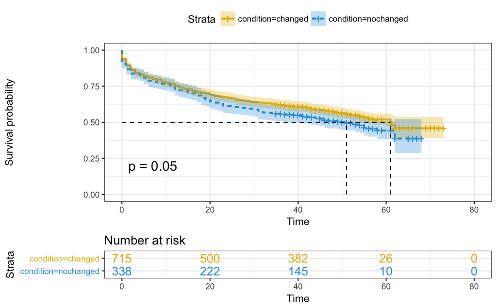

```r
ggsurvplot(fit,
          pval = TRUE, conf.int = TRUE,
          risk.table = TRUE, # Add risk table
          risk.table.col = "strata", # Change risk table color by groups
          linetype = "strata", # Change line type by groups
          surv.median.line = "hv", # Specify median survival
          ggtheme = theme_bw(), # Change ggplot2 theme
          palette = c("#E7B800", "#2E9FDF"))
```

```r
survdiff(Surv(lifetime, attritioned) ~ condition, data=choosing_own_intervention_data)
```

```
Call:
survdiff(formula = Surv(lifetime, attritioned) ~ condition, data = choosing_own_intervention_data)

                      N Observed Expected (O-E)^2/E (O-E)^2/V
condition=changed   715      327      347      1.15      3.86
condition=nochanged 338      174      154      2.60      3.86

 Chisq= 3.9  on 1 degrees of freedom, p= 0.0495
```

```r
coxresult <- coxph(Surv(lifetime, attritioned) ~ condition, data=choosing_own_intervention_data)
summary(coxresult)
```

```
Call:
coxph(formula = Surv(lifetime, attritioned) ~ condition, data = choosing_own_intervention_data)

  n= 1053, number of events= 501

                     coef exp(coef) se(coef)     z Pr(>|z|)
conditionnochanged 0.1849    1.2031   0.0939 1.969   0.0489 *
---
Signif. codes:  0 '***' 0.001 '**' 0.01 '*' 0.05 '.' 0.1 ' ' 1

                   exp(coef) exp(-coef) lower .95 upper .95
conditionnochanged     1.203     0.8312     1.001     1.446

Concordance= 0.52  (se = 0.011 )
Rsquare= 0.004   (max possible= 0.998 )
Likelihood ratio test= 3.8  on 1 df,   p=0.05118
Wald test            = 3.88  on 1 df,   p=0.0489
Score (logrank) test = 3.89  on 1 df,   p=0.04858
```

Are there differences in attrition rates between same, random_half, and random conditions in the old experiment

```r
library("survival")
library("survminer")
fit <- survfit(Surv(lifetime, attritioned) ~ condition, data=survivaldata)
summary(fit)
```

```
Call: survfit(formula = Surv(lifetime, attritioned) ~ condition, data = survivaldata)

                condition=random
 time n.risk n.event survival std.err lower 95% CI upper 95% CI
    0    122       9    0.926  0.0237        0.881        0.974
    1    113       4    0.893  0.0279        0.840        0.950
    2    109       5    0.852  0.0321        0.792        0.918
    4    104       1    0.844  0.0328        0.782        0.911
    5    103       4    0.811  0.0354        0.745        0.884
    7     99       1    0.803  0.0360        0.736        0.877
    8     98       1    0.795  0.0365        0.727        0.870
   10     97       1    0.787  0.0371        0.717        0.863
   11     96       1    0.779  0.0376        0.708        0.856
   12     95       4    0.746  0.0394        0.673        0.827
   13     91       2    0.730  0.0402        0.655        0.813
```

[output cut: 76 more lines]

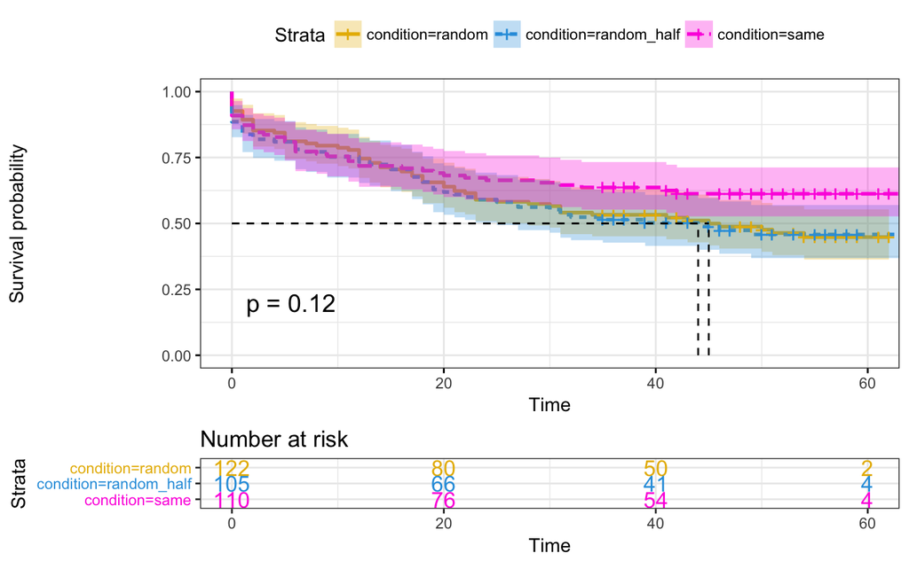

```r
ggsurvplot(fit,
          pval = TRUE, conf.int = TRUE,
          risk.table = TRUE, # Add risk table
          risk.table.col = "strata", # Change risk table color by groups
          linetype = "strata", # Change line type by groups
          surv.median.line = "hv", # Specify median survival
          ggtheme = theme_bw(), # Change ggplot2 theme
          palette = c("#E7B800", "#2E9FDF", "#FD2FDF"))
```

```r
survdiff(Surv(lifetime, attritioned) ~ condition, data=survivaldata)
```

```
Call:
survdiff(formula = Surv(lifetime, attritioned) ~ condition, data = survivaldata)

                        N Observed Expected (O-E)^2/E (O-E)^2/V
condition=random      122       64     58.1     0.594     0.959
condition=random_half 105       55     48.7     0.820     1.213
condition=same        110       42     54.2     2.744     4.270

 Chisq= 4.3  on 2 degrees of freedom, p= 0.117
```

```r
coxresult <- coxph(Surv(lifetime, attritioned) ~ condition, data=survivaldata)
summary(coxresult)
```

```
Call:
coxph(formula = Surv(lifetime, attritioned) ~ condition, data = survivaldata)

  n= 337, number of events= 161

                         coef exp(coef) se(coef)      z Pr(>|z|)
conditionrandom_half  0.02969   1.03013  0.18388  0.161   0.8717
conditionsame        -0.35205   0.70325  0.19868 -1.772   0.0764 .
---
Signif. codes:  0 '***' 0.001 '**' 0.01 '*' 0.05 '.' 0.1 ' ' 1

                     exp(coef) exp(-coef) lower .95 upper .95
conditionrandom_half    1.0301     0.9708    0.7184     1.477
conditionsame           0.7032     1.4220    0.4764     1.038

Concordance= 0.533  (se = 0.023 )
Rsquare= 0.013   (max possible= 0.995 )
Likelihood ratio test= 4.4  on 2 df,   p=0.1107
Wald test            = 4.17  on 2 df,   p=0.1241
Score (logrank) test = 4.22  on 2 df,   p=0.1212
```

Are there differences in attrition rates between same and random_half conditions in the old experiment

```r
library("survival")
library("survminer")
curdata <- subset(survivaldata, condition ==  'random_half' | condition == 'same')
fit <- survfit(Surv(lifetime, attritioned) ~ condition, data=curdata)
summary(fit)
```

```
Call: survfit(formula = Surv(lifetime, attritioned) ~ condition, data = curdata)

                condition=random_half
 time n.risk n.event survival std.err lower 95% CI upper 95% CI
    0    105      12    0.886  0.0310        0.827        0.949
    1     93       5    0.838  0.0359        0.771        0.912
    2     88       2    0.819  0.0376        0.749        0.896
    4     86       1    0.810  0.0383        0.738        0.888
    6     85       3    0.781  0.0404        0.706        0.864
    7     82       1    0.771  0.0410        0.695        0.856
    9     81       2    0.752  0.0421        0.674        0.840
   12     79       2    0.733  0.0432        0.653        0.823
   13     77       1    0.724  0.0436        0.643        0.815
   15     76       2    0.705  0.0445        0.623        0.798
   17     74       3    0.676  0.0457        0.592        0.772
```

[output cut: 41 more lines]

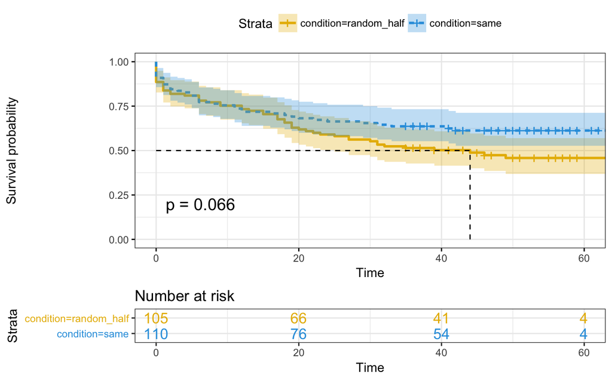

```r
ggsurvplot(fit,
          pval = TRUE, conf.int = TRUE,
          risk.table = TRUE, # Add risk table
          risk.table.col = "strata", # Change risk table color by groups
          linetype = "strata", # Change line type by groups
          surv.median.line = "hv", # Specify median survival
          ggtheme = theme_bw(), # Change ggplot2 theme
          palette = c("#E7B800", "#2E9FDF"))
```

```r
survdiff(Surv(lifetime, attritioned) ~ condition, data=curdata)
```

```
Call:
survdiff(formula = Surv(lifetime, attritioned) ~ condition, data = curdata)

                        N Observed Expected (O-E)^2/E (O-E)^2/V
condition=random_half 105       55     46.1      1.71      3.38
condition=same        110       42     50.9      1.55      3.38

 Chisq= 3.4  on 1 degrees of freedom, p= 0.0659
```

```r
coxresult <- coxph(Surv(lifetime, attritioned) ~ condition, data=curdata)
```

```
X matrix deemed to be singular; variable 2
```

```r
summary(coxresult)
```

```
Call:
coxph(formula = Surv(lifetime, attritioned) ~ condition, data = curdata)

  n= 215, number of events= 97

                       coef exp(coef) se(coef)     z Pr(>|z|)
conditionrandom_half 0.3730    1.4520   0.2051 1.819    0.069 .
conditionsame            NA        NA   0.0000    NA       NA
---
Signif. codes:  0 '***' 0.001 '**' 0.01 '*' 0.05 '.' 0.1 ' ' 1

                     exp(coef) exp(-coef) lower .95 upper .95
conditionrandom_half     1.452     0.6887    0.9714      2.17
conditionsame               NA         NA        NA        NA

Concordance= 0.539  (se = 0.027 )
Rsquare= 0.015   (max possible= 0.99 )
Likelihood ratio test= 3.34  on 1 df,   p=0.06747
Wald test            = 3.31  on 1 df,   p=0.06898
Score (logrank) test = 3.35  on 1 df,   p=0.06739
```

Are there differences in attrition rates between same and random conditions in the old experiment

```r
library("survival")
library("survminer")
curdata <- subset(survivaldata, condition ==  'random' | condition == 'same')
fit <- survfit(Surv(lifetime, attritioned) ~ condition, data=curdata)
summary(fit)
```

```
Call: survfit(formula = Surv(lifetime, attritioned) ~ condition, data = curdata)

                condition=random
 time n.risk n.event survival std.err lower 95% CI upper 95% CI
    0    122       9    0.926  0.0237        0.881        0.974
    1    113       4    0.893  0.0279        0.840        0.950
    2    109       5    0.852  0.0321        0.792        0.918
    4    104       1    0.844  0.0328        0.782        0.911
    5    103       4    0.811  0.0354        0.745        0.884
    7     99       1    0.803  0.0360        0.736        0.877
    8     98       1    0.795  0.0365        0.727        0.870
   10     97       1    0.787  0.0371        0.717        0.863
   11     96       1    0.779  0.0376        0.708        0.856
   12     95       4    0.746  0.0394        0.673        0.827
   13     91       2    0.730  0.0402        0.655        0.813
```

[output cut: 46 more lines]

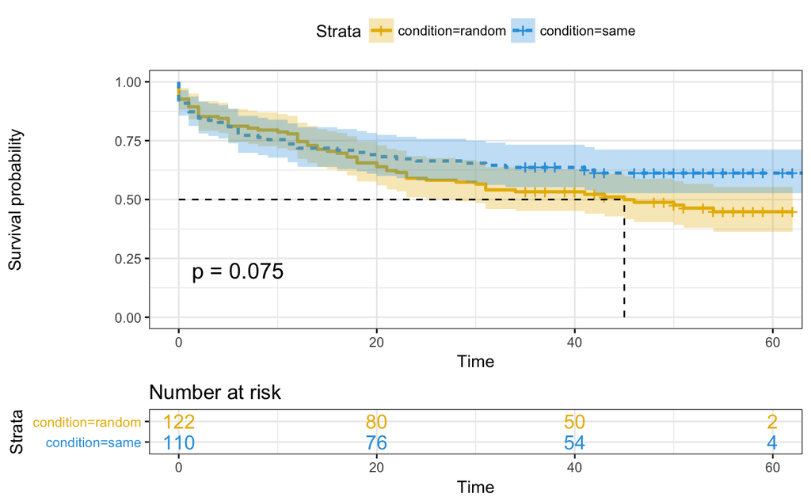

```r
ggsurvplot(fit,
          pval = TRUE, conf.int = TRUE,
          risk.table = TRUE, # Add risk table
          risk.table.col = "strata", # Change risk table color by groups
          linetype = "strata", # Change line type by groups
          surv.median.line = "hv", # Specify median survival
          ggtheme = theme_bw(), # Change ggplot2 theme
          palette = c("#E7B800", "#2E9FDF"))
```

```r
survdiff(Surv(lifetime, attritioned) ~ condition, data=curdata)
```

```
Call:
survdiff(formula = Surv(lifetime, attritioned) ~ condition, data = curdata)

                   N Observed Expected (O-E)^2/E (O-E)^2/V
condition=random 122       64       55      1.49      3.18
condition=same   110       42       51      1.60      3.18

 Chisq= 3.2  on 1 degrees of freedom, p= 0.0747
```

```r
coxresult <- coxph(Surv(lifetime, attritioned) ~ condition, data=curdata)
```

```
X matrix deemed to be singular; variable 1
```

```r
summary(coxresult)
```

```
Call:
coxph(formula = Surv(lifetime, attritioned) ~ condition, data = curdata)

  n= 232, number of events= 106

                        coef exp(coef) se(coef)      z Pr(>|z|)
conditionrandom_half      NA        NA   0.0000     NA       NA
conditionsame        -0.3483    0.7059   0.1987 -1.753   0.0796 .
---
Signif. codes:  0 '***' 0.001 '**' 0.01 '*' 0.05 '.' 0.1 ' ' 1

                     exp(coef) exp(-coef) lower .95 upper .95
conditionrandom_half        NA         NA        NA        NA
conditionsame           0.7059      1.417    0.4781     1.042

Concordance= 0.53  (se = 0.026 )
Rsquare= 0.013   (max possible= 0.991 )
Likelihood ratio test= 3.13  on 1 df,   p=0.07677
Wald test            = 3.07  on 1 df,   p=0.07963
Score (logrank) test = 3.1  on 1 df,   p=0.07812
```

*SIGNIFICANT* Are there differences in attrition rates between same and random conditions in the old experiment (where people in the same=one intervention condition were seeing that same one forever, and random=all_default combined with half_defaults were always seeing random interventions)

```r
library("survival")
library("survminer")
fit <- survfit(Surv(lifetime, attritioned) ~ condition, data=survivaldata_grouped)
summary(fit)
```

```
Call: survfit(formula = Surv(lifetime, attritioned) ~ condition, data = survivaldata_grouped)

                condition=random
 time n.risk n.event survival std.err lower 95% CI upper 95% CI
    0    227      21    0.907  0.0192        0.871        0.946
    1    206       9    0.868  0.0225        0.825        0.913
    2    197       7    0.837  0.0245        0.790        0.886
    4    190       2    0.828  0.0250        0.781        0.879
    5    188       4    0.811  0.0260        0.761        0.863
    6    184       3    0.797  0.0267        0.747        0.851
    7    181       2    0.789  0.0271        0.737        0.843
    8    179       1    0.784  0.0273        0.732        0.840
    9    178       2    0.775  0.0277        0.723        0.832
   10    176       1    0.771  0.0279        0.718        0.828
   11    175       1    0.767  0.0281        0.713        0.824
```

[output cut: 55 more lines]

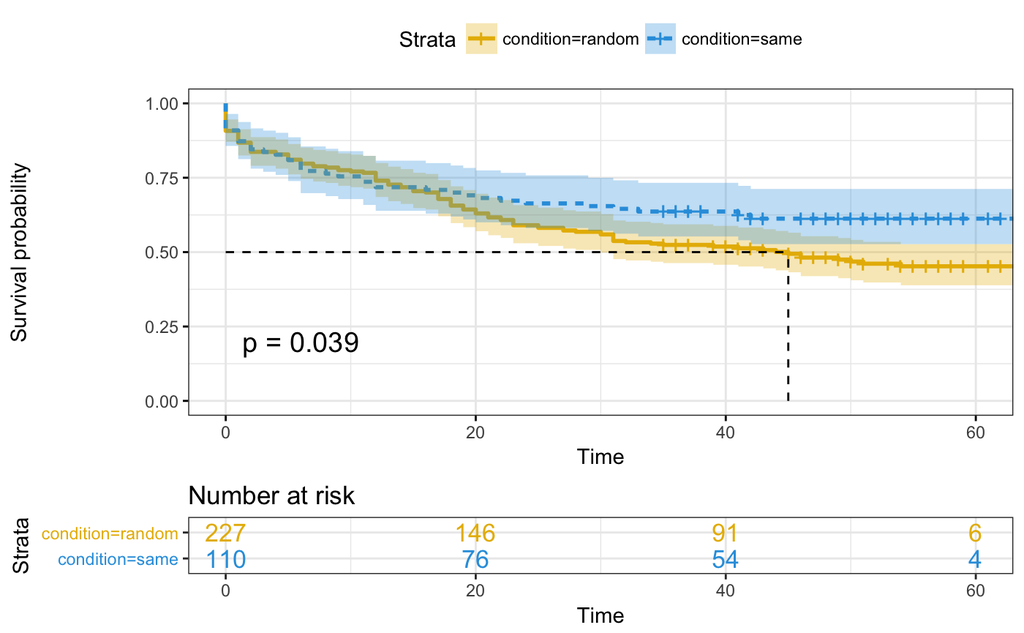

```r
ggsurvplot(fit,
          pval = TRUE, conf.int = TRUE,
          risk.table = TRUE, # Add risk table
          risk.table.col = "strata", # Change risk table color by groups
          linetype = "strata", # Change line type by groups
          surv.median.line = "hv", # Specify median survival
          ggtheme = theme_bw(), # Change ggplot2 theme
          palette = c("#E7B800", "#2E9FDF", "#FD2FDF"))
```

```r
survdiff(Surv(lifetime, attritioned) ~ condition, data=survivaldata_grouped)
```

```
Call:
survdiff(formula = Surv(lifetime, attritioned) ~ condition, data = survivaldata_grouped)

                   N Observed Expected (O-E)^2/E (O-E)^2/V
condition=random 227      119    106.8      1.39      4.27
condition=same   110       42     54.2      2.74      4.27

 Chisq= 4.3  on 1 degrees of freedom, p= 0.0388
```

```r
coxresult <- coxph(Surv(lifetime, attritioned) ~ condition, data=survivaldata_grouped)
summary(coxresult)
```

```
Call:
coxph(formula = Surv(lifetime, attritioned) ~ condition, data = survivaldata_grouped)

  n= 337, number of events= 161

                 coef exp(coef) se(coef)      z Pr(>|z|)
conditionsame -0.3657    0.6937   0.1796 -2.036   0.0418 *
---
Signif. codes:  0 '***' 0.001 '**' 0.01 '*' 0.05 '.' 0.1 ' ' 1

              exp(coef) exp(-coef) lower .95 upper .95
conditionsame    0.6937      1.441    0.4879    0.9865

Concordance= 0.529  (se = 0.02 )
Rsquare= 0.013   (max possible= 0.995 )
Likelihood ratio test= 4.38  on 1 df,   p=0.03644
Wald test            = 4.14  on 1 df,   p=0.04176
Score (logrank) test = 4.19  on 1 df,   p=0.04064
```

```r
summary(data_peruser)
```

```
 attritioned     attritioned_during_first_condition completed_first_condition days_kept_installed
 Mode :logical   Mode :logical                      Mode :logical             Min.   : 0.000
 FALSE:76        FALSE:144                          FALSE:113                 1st Qu.: 0.000
 TRUE :141       TRUE :73                           TRUE :104                 Median : 2.000
                                                                              Mean   : 4.636
                                                                              3rd Qu.: 7.000
                                                                              Max.   :21.000

 first_condition_for_user first_conditionduration_for_user                    install_id
 random:120               Min.   :1.000                    001759e5af383d861c7b02b5:  1
 same  : 97               1st Qu.:3.000                    06d80d6afa3f1fc8ba8eb47f:  1
                          Median :5.000                    07b811c2ce81c4533ea52df4:  1
                          Mean   :4.124                    07c09e33df1c91f7d77ed696:  1
                          3rd Qu.:7.000                    0825c041b139e5c53871a0b9:  1
                          Max.   :7.000                    08c5e36f3aaf25825a206b92:  1
                                                           (Other)                 :211
 did_not_complete_first_condition
 Mode :logical
 FALSE:104
 TRUE :113
```

```r
library("survival")
library("survminer")
data_peruser$first_condition_for_user <- factor(data_peruser$first_condition_for_user, levels=c("same", "random"))
fit <- survfit(Surv(days_kept_installed, attritioned_during_first_condition) ~ first_condition_for_user, data=data_peruser)
#fit <- survfit(Surv(days_kept_installed, did_not_complete_first_condition) ~ first_condition_for_user, data=data_peruser)
summary(fit)
```

```
Call: survfit(formula = Surv(days_kept_installed, attritioned_during_first_condition) ~
    first_condition_for_user, data = data_peruser)

                first_condition_for_user=same
 time n.risk n.event survival std.err lower 95% CI upper 95% CI
    0     97      18    0.814  0.0395        0.741        0.896
    1     67       3    0.778  0.0430        0.698        0.867
    2     55       2    0.750  0.0458        0.665        0.845
    6     39       1    0.730  0.0485        0.641        0.832

                first_condition_for_user=random
 time n.risk n.event survival std.err lower 95% CI upper 95% CI
    0    120      25    0.792  0.0371        0.722        0.868
    1     83       9    0.706  0.0427        0.627        0.795
    2     67       5    0.653  0.0455        0.570        0.749
    3     56       3    0.618  0.0474        0.532        0.718
    4     51       5    0.558  0.0499        0.468        0.664
    6     37       2    0.527  0.0515        0.435        0.639
```

```r
ggsurvplot(fit,
          pval = FALSE, conf.int = TRUE,
          risk.table = FALSE, # Add risk table
          risk.table.col = "strata", # Change risk table color by groups
          linetype = "strata", # Change line type by groups
          surv.median.line = "none", # Specify median survival
          ggtheme = theme_bw(), # Change ggplot2 theme
          palette = c("#E7B800", "#2E9FDF"),
          xlab="Days HabitLab is installed",
          xlim=c(0, 7),
          break.x.by = 1,
          legend="bottom",
          legend.labs = c("Static", "Rotation")
          )
```

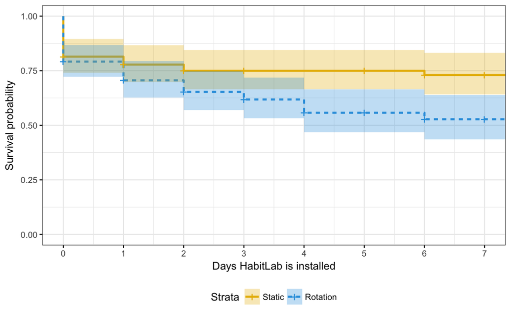

```r
ggsave(paste(basepath, 'attrition_within_subjects.png', sep=''), width = 7.5, height = 4, units="in")
```

```r
survdiff(Surv(days_kept_installed, attritioned_during_first_condition) ~ first_condition_for_user, data=data_peruser)
```

```
Call:
survdiff(formula = Surv(days_kept_installed, attritioned_during_first_condition) ~
    first_condition_for_user, data = data_peruser)

                                  N Observed Expected (O-E)^2/E (O-E)^2/V
first_condition_for_user=same    97       24     33.1      2.49      5.26
first_condition_for_user=random 120       49     39.9      2.06      5.26

 Chisq= 5.3  on 1 degrees of freedom, p= 0.0218
```

```r
summary(data_peruser)
```

```
 attritioned     attritioned_during_first_condition completed_first_condition days_kept_installed
 Mode :logical   Mode :logical                      Mode :logical             Min.   : 0.000
 FALSE:76        FALSE:144                          FALSE:113                 1st Qu.: 0.000
 TRUE :141       TRUE :73                           TRUE :104                 Median : 2.000
                                                                              Mean   : 4.636
                                                                              3rd Qu.: 7.000
                                                                              Max.   :21.000

 first_condition_for_user first_conditionduration_for_user                    install_id
 same  : 97               Min.   :1.000                    001759e5af383d861c7b02b5:  1
 random:120               1st Qu.:3.000                    06d80d6afa3f1fc8ba8eb47f:  1
                          Median :5.000                    07b811c2ce81c4533ea52df4:  1
                          Mean   :4.124                    07c09e33df1c91f7d77ed696:  1
                          3rd Qu.:7.000                    0825c041b139e5c53871a0b9:  1
                          Max.   :7.000                    08c5e36f3aaf25825a206b92:  1
                                                           (Other)                 :211
 did_not_complete_first_condition days_in_firstcondition
 Mode :logical                    Min.   :0.000
 FALSE:104                        1st Qu.:0.000
 TRUE :113                        Median :1.000
                                  Mean   :2.147
                                  3rd Qu.:3.000
                                  Max.   :7.000
```